# Zwischenbericht MSB

- Show All Code
- Hide All Code
- View Source

Author

Affiliation

Jürgen Schneider

DIPF

Published

June 12, 2024

# 1 Preparation

**Import data**

```r
k1k2 <- rio::import(here("data/07_LSI_MZP123456_Lehramtneu_Unicode.sav"))

k3_laa <- rio::import(here("data/LAA_K3_2024-04-11.sav")) # K3 der LAA MZP 1 und MZP 2
k3_alk_mzp1 <- rio::import(here("data/ALK_K3_MZP1_2022-04-04_Unicode.sav")) # K3 der ALK aus MZP 1
k3_sab_mzp1 <- rio::import(here("data/SAB_K3_MZP1_2022-04-20.sav")) # K3 der SAB aus MZP 1

k4_laa_mzp1 <- rio::import(here("data/LAA_K4_MZP1_2024-04-15.sav")) # K4 der LAA aus MZP 1
k4_alk_mzp1 <- rio::import(here("data/ALK_K4_MZP1_2024-05-22.sav")) # K4 der ALK aus MZP 1
k4_sab_mzp1 <- rio::import(here("data/SAB_K4_MZP1_2024-03-11.sav")) # K4 der SAB aus MZP 1
```

**Data wrangling**

Auswahl der Skalen und wrangling der Daten.

### 1.0.1 K1 & K2 LAA

```r
k1k2_clean <- k1k2 |>
  dplyr::mutate(kohorte = as.factor(kohorte),
                 ee_1 = rowMeans(data.frame(ee_a_1,
                                            ee_b_1,
                                            ee_c_1,
                                            ee_d_1))) |>
  dplyr::select(kohorte,
                UL_1,
                LE_1,
                DE_1,
                BT_1,
                SP_1,
                LB_1,
                entu_1,
                entf_1,
                efft_1,
                ee_1,
                ee_3,
                engak_1,
                aen_3,
                uebr_1,
                uebk_1) |>
  dplyr::rename_with(~ gsub("_1", "", .x, fixed = TRUE)) |> # Löschen von _01 in den Variablennamen
  dplyr::rename(c(BilWiss_ul = UL,         # umbenennen der Variblen für das Matching
                  BilWiss_le = LE,
                  BilWiss_de = DE,
                  BilWiss_bt = BT,
                  BilWiss_sb = SP,
                  BilWiss_lb = LB,
                  bel = ee,
                  aen = engak)) |>
  dplyr::mutate(gruppe = as.factor("laa"),   # Variable zur Unterscheidung der Gruppen
                efft = (efft/7)*4,   # rescale to fit K3 and K4
                aen = (aen/7)*4)
```

### 1.0.2 K3 LAA

```r
k3_laa_clean <- k3_laa |>
  dplyr::select(Score_Kurz_01,               # Auswahl der Variablen
                Score_BT_KT_01,
                Score_DE_KT_01,
                Score_LB_KT_01,
                Score_LE_KT_01,
                Score_SB_KT_01,
                Score_UN_KT_01,
                tp_01,
                entu_01,
                entf_01,
                efft_01,
                rfbe_01,
                meko_1_01 : meko_7_01,
                mekos_01,
                bel_01,
                aen_01,
                zfr_01,
                uebr_01,
                uebk_01) |>
  dplyr::rename_with(~ gsub("_01", "", .x, fixed = TRUE)) |> # Löschen von _01 in den Variablennamen
  dplyr::rename(c(BilWiss_kurz = Score_Kurz,         # umbenennen der Variblen für das Matching
                  BilWiss_ul = Score_UN_KT,
                  BilWiss_le = Score_LE_KT,
                  BilWiss_de = Score_DE_KT,
                  BilWiss_bt = Score_BT_KT,
                  BilWiss_sb = Score_SB_KT,
                  BilWiss_lb = Score_LB_KT)) |>
  dplyr::mutate(kohorte = as.factor("3"),    # Variable zur Unterscheidung der Kohorten
                gruppe = as.factor("laa"))   # Variable zur Unterscheidung der Gruppen
```

### 1.0.3 K4 LAA

```r
k4_laa_mzp1_clean <- k4_laa_mzp1 |>
  dplyr::select(xgender_01K4,             # Auswahl der Variablen
                xage_01K4,
                xsem_01K4,
                Score_Kurz_01K4,
                Score_BT_KT_01K4,
                Score_DE_KT_01K4,
                Score_LB_KT_01K4,
                Score_LE_KT_01K4,
                Score_SB_KT_01K4,
                Score_UN_KT_01K4,
                tp_01K4,
                entu_01K4,
                entf_01K4,
                efft_01K4,
                rfbe_01K4,
                meko_1_01K4 : meko_7_01K4,
                mekos_01K4,
                tpkcon_score_01K4,
                tpksit_score_01K4,
                tpkpot_score_01K4,
                tpksup_score_01K4,
                tpksit_score_av_01K4,
                tpksit_score_tb_01K4,
                tpksit_score_aa_01K4,
                bel_01K4,
                aen_01K4,
                zfr_01K4,
                palk_01K4,
                palaz_01K4,
                palvz_01K4,
                uebr_01K4,
                uebk_01K4,
                ub_8_01K4,
                ub_3_01K4,
                ub_7_01K4) |>
  dplyr::rename_with(~ gsub("_01K4", "", .x, fixed = TRUE)) |> # Löschen von _01K4 in den Variablennamen
  dplyr::rename(c(BilWiss_kurz = Score_Kurz,         # umbenennen der Variblen für das Matching
                  BilWiss_ul = Score_UN_KT,
                  BilWiss_le = Score_LE_KT,
                  BilWiss_de = Score_DE_KT,
                  BilWiss_bt = Score_BT_KT,
                  BilWiss_sb = Score_SB_KT,
                  BilWiss_lb = Score_LB_KT)) |>
  dplyr::mutate(kohorte = as.factor("4"),    # Variable zur Unterscheidung der Kohorten
                gruppe = as.factor("laa"))   # Variable zur Unterscheidung der Gruppen
```

### 1.0.4 K3 ALK

```r
k3_alk_mzp1_clean <- k3_alk_mzp1 |>
  dplyr::select(aunlt_01,             # Auswahl der Variablen
                aunl_01,
                # INNO_01, # nicht in den Daten & in Skalendoku
                EE_01,
                ENGA_01,
                ZFR_01,
                QUIT_01,
                eignp_01,
                eign_01_01,
                soz_1_01, # hier gibt es einzelne Items, die erst in eine Skala gebracht werden müssen
                soz_2_01,
                soz_3_01,
                koop_01) |>
  dplyr::mutate(SOZ_01 = rowMeans(data.frame(soz_1_01, soz_2_01, soz_3_01))) |>
  dplyr::select(-c(soz_1_01, soz_2_01, soz_3_01)) |>
  dplyr::rename_with(~ gsub("_01", "", .x, fixed = TRUE)) |> # Löschen von _01K4 in den Variablennamen
  dplyr::rename(c(bel = EE,                       # umbenennen der Variblen für das Matching
                  aen = ENGA,
                  zfr = ZFR,
                  uebr = aunlt,
                  uebk = aunl,
                  KOZA = koop,
                  eign_01 = eign)) |>
  dplyr::mutate(kohorte = as.factor("3"),    # Variable zur Unterscheidung der Kohorten
                gruppe = as.factor("alk"))   # Variable zur Unterscheidung der Gruppen
```

### 1.0.5 K4 ALK

```r
k4_alk_mzp1_clean <- k4_alk_mzp1 |>
  dplyr::select(AUNLT_01K4,             # Auswahl der Variablen
                AUNL_01K4,
                INNO_01K4,
                EE_01K4,
                ENGA_01K4,
                ZFR_01K4,
                QUIT_01K4,
                # LZ_01K4,   # In der Skalendoku aber nicht im Datensatz
                eignp_01K4,
                eign_01_01K4,
                KOOP_01K4,
                SOZ_01K4,
                ubvorA_1_01K4,
                ubvorB_1_01K4,
                ubvorC_1_01K4,
                ubvorA1X_01K4,
                ubvorB1X_01K4,
                ubvorC1X_01K4,
                ubnach_1_01K4,
                ubnach_2_01K4,
                ubnach_3_01K4,
                ubnach_4_01K4,
                tpkcon_score_01K4,
                tpksit_score_01K4,
                tpkpot_score_01K4,
                tpksup_score_01K4,
                tpksit_score_av_01K4,
                tpksit_score_tb_01K4,
                tpksit_score_aa_01K4) |>
  dplyr::rename_with(~ gsub("_01K4", "", .x, fixed = TRUE)) |> # Löschen von _01K4 in den Variablennamen
  dplyr::rename(c(KOZA = KOOP,                       # umbenennen der Variblen für das Matching
                  bel = EE,
                  aen = ENGA,
                  zfr = ZFR,
                  uebr = AUNLT,
                  uebk = AUNL)) |>
  dplyr::mutate(kohorte = as.factor("4"),    # Variable zur Unterscheidung der Kohorten
                gruppe = as.factor("alk"))   # Variable zur Unterscheidung der Gruppen
```

### 1.0.6 K3 SAB

```r
k3_sab_mzp1_clean <- k3_sab_mzp1 |>
  dplyr::select(AUNLT_01,             # Auswahl der Variablen
                AUNL_01,
                # INNO_01, # nicht in den Daten & in Skalendoku
                SETH_FA_01,
                SETH_KA_01,
                EXKO_01,
                EE_01,
                ENGA_01,
                ZFR_01,
                QUIT_01,
                SExFAP_01,
                SExKAP_01,
                LZ_01,
                KOZA_01#,
                # SOZ_01,  # nicht in den Daten & in Skalendoku
                ) |>
  dplyr::rename_with(~ gsub("_01", "", .x, fixed = TRUE)) |> # Löschen von _01K4 in den Variablennamen
  dplyr::rename(c(bel = EE, # umbenennen der Variblen für das Matching
                  aen = ENGA,
                  zfr = ZFR,
                  uebr = AUNLT,
                  uebk = AUNL)) |>
  dplyr::mutate(kohorte = as.factor("3"),    # Variable zur Unterscheidung der Kohorten
                gruppe = as.factor("sab"))   # Variable zur Unterscheidung der Gruppen
```

### 1.0.7 K4 SAB

```r
k4_sab_mzp1_clean <- k4_sab_mzp1 |>
  dplyr::select(AUNLT_01K4,             # Auswahl der Variablen
                AUNL_01K4,
                TPZU_01K4,
                INNO_01K4,
                EXKO_01K4,
                EE_01K4,
                ENGA_01K4,
                ZFR_01K4,
                QUIT_01K4,
                SExMPART_01K4,
                SExFAP_01K4,
                SExKAP_01K4,
                LZ_01K4,
                eignp_01K4,
                eign_01_01K4,
                KOZA_01K4,
                SOZ_01K4,
                MEKOS_01K4,
                tpkcon_score_01K4,
                tpksit_score_01K4,
                tpkpot_score_01K4,
                tpksup_score_01K4,
                tpksit_score_av_01K4,
                tpksit_score_tb_01K4,
                tpksit_score_aa_01K4,
                Filterfrage_01K4) |>
  dplyr::rename_with(~ gsub("_01K4", "", .x, fixed = TRUE)) |> # Löschen von _01K4 in den Variablennamen
  dplyr::rename(c(bel = EE,                       # umbenennen der Variblen für das Matching
                  aen = ENGA,
                  zfr = ZFR,
                  uebr = AUNLT,
                  uebk = AUNL,
                  mekos = MEKOS)) |>
  dplyr::mutate(kohorte = as.factor("4"),    # Variable zur Unterscheidung der Kohorten
                gruppe = as.factor("sab"))   # Variable zur Unterscheidung der Gruppen
```

**Matching**

```r
nrw <- dplyr::bind_rows(k1k2_clean,
                        k3_laa_clean,
                        k3_alk_mzp1_clean,
                        k3_sab_mzp1_clean,
                        k4_laa_mzp1_clean,
                        k4_alk_mzp1_clean,
                        k4_sab_mzp1_clean)
```

# 2 Stichprobe K4

```r
nrw |>
  dplyr::filter(kohorte == "4", gruppe == "laa") |>
  dplyr::summarize(gender_f = sum(k4_laa_mzp1$xgender == 2, na.rm = T) / sum(!is.na(xgender)),
                   gender_m = sum(k4_laa_mzp1$xgender == 1, na.rm = T) / sum(!is.na(xgender)),
                   gender_d = sum(k4_laa_mzp1$xgender == 3, na.rm = T) / sum(!is.na(xgender)),
                   age_M = mean(xage, na.rm = T),
                   age_SD = SD(xage, na.rm = T),
                   age_min = min(xage, na.rm = T),
                   age_max = max(xage, na.rm = T),
                   LA_Zugang_G         = sum(xsem == 1, na.rm = T),
                   LA_Zugang_HRSGeSekI = sum(xsem == 2, na.rm = T),
                   LA_Zugang_GyGeSekII = sum(xsem == 3, na.rm = T),
                   LA_Zugang_SF        = sum(xsem == 4, na.rm = T),
                   LA_Zugang_BK        = sum(xsem == 5, na.rm = T),
                   LA_Zugang_kein      = sum(xsem == 6, na.rm = T))
```

```
   gender_f  gender_m    gender_d    age_M   age_SD age_min age_max LA_Zugang_G
1 0.7019231 0.2916667 0.006410256 27.84751 3.990446      21      55         129
  LA_Zugang_HRSGeSekI LA_Zugang_GyGeSekII LA_Zugang_SF LA_Zugang_BK
1                 122                 269           55           49
  LA_Zugang_kein
1              0
```

# 3 Analyses

## 3.1 Start in den VB

“Wie starten die LAA in den Vorbereitungsdienst (Vergleiche zu K1, K2, K3)?”

### 3.1.1 BilWiss

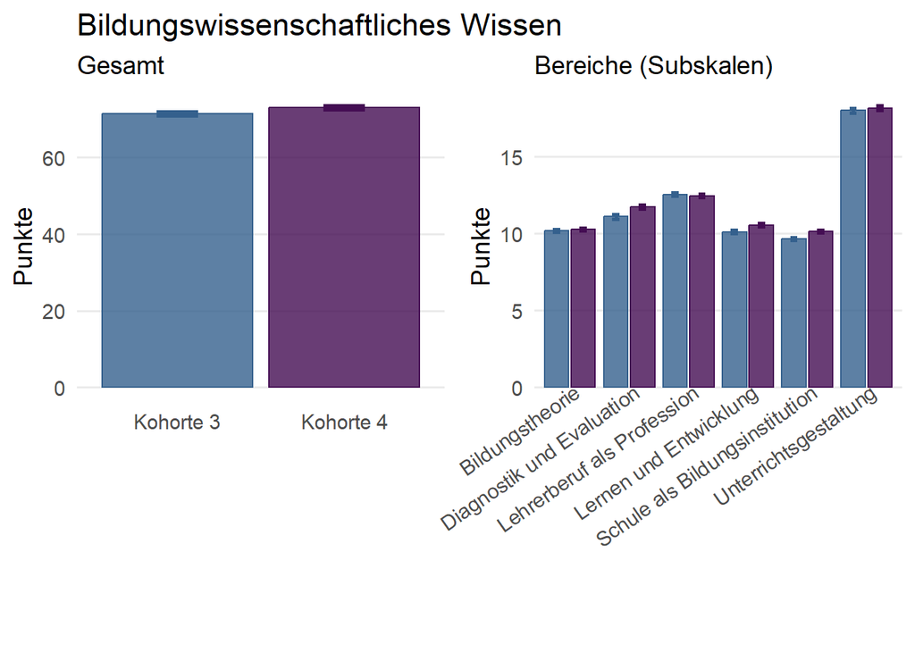

```r
nrw_p <- nrw |>
  dplyr::filter(kohorte %in% c("3", "4") &
                gruppe %in% c("laa"))

p1 <- ggplot(nrw_p, aes(x=kohorte, y = BilWiss_kurz, fill = kohorte, color = kohorte)) +
  stat_summary(geom = "bar", alpha = .8) +
  stat_summary(linewidth = 1, geom = "errorbar", width = .25) +
  scale_x_discrete(labels = c("Kohorte 3", "Kohorte 4")) +
  scale_fill_manual(values = c(#"#fce725",
                               #"#37b877",
                               "#34608d",
                               "#440d53")) +
  scale_color_manual(values = c(#"#fce725",
                               #"#37b877",
                               "#34608d",
                               "#440d53")) +
  xlab("") +
  ylab("Punkte") +
  labs(title = "Bildungswissenschaftliches Wissen",
       subtitle = "Gesamt",
       caption = "",
       fill = "Kohorte",
       color = "Kohorte") +
  theme_minimal(base_size = 14) +
  theme(panel.grid.major.x = element_blank(),
        panel.grid.minor.y = element_blank(),
        legend.position = "none")



rm(nrw_p)
nrw_p <- nrw |>
  dplyr::select(kohorte, BilWiss_ul,
                         BilWiss_le,
                         BilWiss_de,
                         BilWiss_bt,
                         BilWiss_sb,
                         BilWiss_lb) |>
  dplyr::filter(kohorte %in% c("3", "4")) |>
  pivot_longer(2:7, names_to = "variables", values_to = "values")

p2 <- ggplot(nrw_p, aes(x=variables, y = values, fill = kohorte, color = kohorte)) +
  stat_summary(geom = "bar", alpha = .8,
               position = position_dodge2(width = 1)) +
  stat_summary(linewidth = 1, geom = "errorbar",
               width = .25, position = position_dodge(width = .9)) +
  scale_fill_manual(values = c(#"#fce725",
                               #"#37b877",
                               "#34608d",
                               "#440d53")) +
  scale_color_manual(values = c(#"#fce725",
                               #"#37b877",
                               "#34608d",
                               "#440d53")) +
  scale_x_discrete(labels = c("Bildungstheorie",
                              "Diagnostik und Evaluation",
                              "Lehrerberuf als Profession",
                              "Lernen und Entwicklung",
                              "Schule als Bildungsinstitution",
                              "Unterrichtsgestaltung")) +
  xlab("") +
  ylab("Punkte") +
  labs(title = "Bildungswissenschaftliches Wissen",
       subtitle = "Bereiche (Subskalen)",
       caption = "",
       fill = "Kohorte",
       color = "Kohorte") +
  theme_minimal(base_size = 14) +
  theme(axis.text.x = element_text(angle = 35, vjust = 1.2, hjust = 1),
        panel.grid.major.x = element_blank(),
        panel.grid.minor.y = element_blank())


ggarrange(p1, p2 + labs(title = ""),
          ncol = 2,
          align = "hv",
          common.legend = T,
          legend = "none")
```

**BilWiss**  
*t-Test*  
K3 vs. K4

```r
t.test(BilWiss_kurz ~ kohorte,
       data = nrw |> dplyr::filter(kohorte %in% c("3", "4") &
                                   gruppe %in% c("laa")))
```

```
    Welch Two Sample t-test

data:  BilWiss_kurz by kohorte
t = -2.3055, df = 1298.4, p-value = 0.0213
alternative hypothesis: true difference in means between group 3 and group 4 is not equal to 0
95 percent confidence interval:
 -3.1035274 -0.2499413
sample estimates:
mean in group 3 mean in group 4
       71.38336        73.06009
```

*Cohen’s d*

```r
cohens_d <- psych::cohen.d(BilWiss_kurz ~ kohorte,
                           data = nrw |> dplyr::filter(kohorte %in% c("3", "4") &
                                                       gruppe %in% c("laa")))
cohens_d$cohen.d
```

```
                 lower    effect     upper
BilWiss_kurz 0.0185905 0.1265525 0.2344655
```

*Overlap*  
in Prozent

```r
2 * pnorm(-abs(cohens_d$cohen.d[1, "effect"]) / 2) * 100
```

```
[1] 94.95465
```

### 3.1.2 Aspekte professioneller Kompetenz

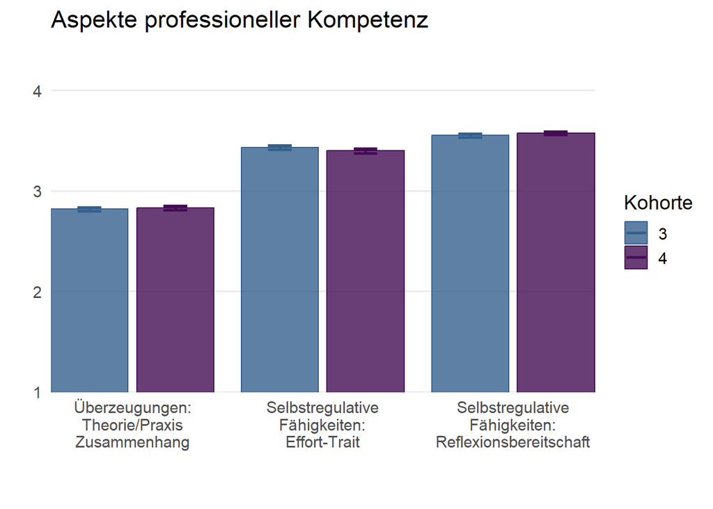

```r
rm(nrw_p)
nrw_p <- nrw |>
  dplyr::filter(kohorte %in% c("3", "4") &
                gruppe %in% c("laa")) |>
  dplyr::select(kohorte, tp,
                         efft,
                         rfbe) |>
  pivot_longer(2:4, names_to = "variables", values_to = "values")

p1 <- ggplot(nrw_p, aes(x=factor(variables,
                                 levels = c("tp", "efft", "rfbe")),
                        y = values,
                        fill = kohorte,
                        color = kohorte)) +
  stat_summary(geom = "bar", alpha = .8,
               position = position_dodge2(width = 1)) +
  stat_summary(linewidth = 1, geom = "errorbar",
               width = .25, position = position_dodge(width = .9)) +
  scale_fill_manual(values = c(#"#fce725",
                               #"#37b877",
                               "#34608d",
                               "#440d53")) +
  scale_color_manual(values = c(#"#fce725",
                                #"#37b877",
                                "#34608d",
                                "#440d53")) +
  scale_x_discrete(labels = c("Überzeugungen:\nTheorie/Praxis\nZusammenhang",
                              "Selbstregulative\nFähigkeiten:\nEffort-Trait",
                              "Selbstregulative\nFähigkeiten:\nReflexionsbereitschaft")) +
  coord_cartesian(ylim=c(1,4.2),
                  expand = F) +
  xlab("") +
  ylab("") +
  labs(title = "Aspekte professioneller Kompetenz",
       subtitle = "",
       caption = "",
       fill = "Kohorte",
       color = "Kohorte") +
  theme_minimal(base_size = 14) +
  theme(#axis.text.x = element_text(angle = 35, vjust = 1, hjust=1),
        panel.grid.major.x = element_blank(),
        panel.grid.minor.y = element_blank())

p1
```

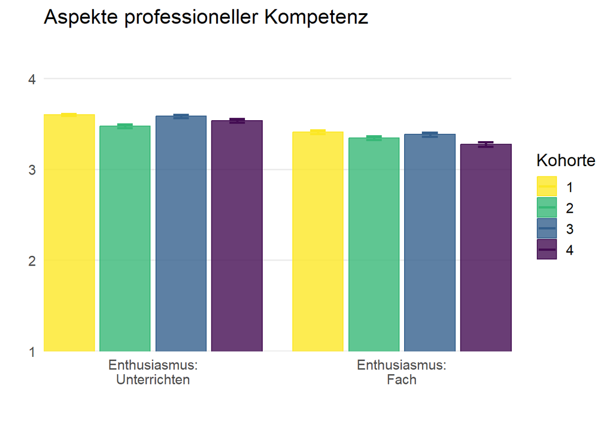

```r
rm(nrw_p)
nrw_p <- nrw |>
  dplyr::filter(gruppe %in% c("laa")) |>
  dplyr::select(kohorte, entu,
                         entf) |>
  pivot_longer(2:3, names_to = "variables", values_to = "values")

p2 <- ggplot(nrw_p, aes(x=factor(variables,
                                 levels = c("entu", "entf")),
                        y = values,
                        fill = kohorte,
                        color = kohorte)) +
  stat_summary(geom = "bar", alpha = .8,
               position = position_dodge2(width = 1)) +
  stat_summary(linewidth = 1, geom = "errorbar",
               width = .25, position = position_dodge(width = .9)) +
  scale_fill_manual(values = c("#fce725",
                               "#37b877",
                               "#34608d",
                               "#440d53")) +
  scale_color_manual(values = c("#fce725",
                                "#37b877",
                                "#34608d",
                                "#440d53")) +
  scale_x_discrete(labels = c("Enthusiasmus:\nUnterrichten",
                              "Enthusiasmus:\nFach")) +
  coord_cartesian(ylim=c(1,4.2),
                  expand = F) +
  xlab("") +
  ylab("") +
  labs(title = "Aspekte professioneller Kompetenz",
       subtitle = "",
       caption = "",
       fill = "Kohorte",
       color = "Kohorte") +
  theme_minimal(base_size = 14) +
  theme(#axis.text.x = element_text(angle = 35, vjust = 1, hjust=1),
        panel.grid.major.x = element_blank(),
        panel.grid.minor.y = element_blank())

p2
```

**Enthusiasmus unterrichten**  
*ANOVA*  
K1 vs. K2 vs. K3 vs. K4

```r
fit_aov <- aov(scale(entu) ~ kohorte,
               data = nrw |> dplyr::filter(gruppe %in% c("laa")))
summary(fit_aov)
```

```
              Df Sum Sq Mean Sq F value   Pr(>F)
kohorte        3   33.6   11.21   11.33 2.19e-07 ***
Residuals   3057 3026.4    0.99
---
Signif. codes:  0 '***' 0.001 '**' 0.01 '*' 0.05 '.' 0.1 ' ' 1
2323 Beobachtungen als fehlend gelöscht
```

*Kontraste*  
p-Werte adjustiert nach Tukey.  
Werte unter “estimate” sind Cohen’d äquivalent zu interpretieren.

```r
pairs(lsmeans(fit_aov, ~ kohorte))
```

```
 contrast            estimate     SE   df t.ratio p.value
 kohorte1 - kohorte2   0.2881 0.0529 3057   5.441  <.0001
 kohorte1 - kohorte3   0.0358 0.0475 3057   0.753  0.8754
 kohorte1 - kohorte4   0.1512 0.0490 3057   3.087  0.0110
 kohorte2 - kohorte3  -0.2524 0.0597 3057  -4.230  0.0001
 kohorte2 - kohorte4  -0.1369 0.0609 3057  -2.249  0.1104
 kohorte3 - kohorte4   0.1155 0.0562 3057   2.056  0.1681

Note: contrasts are still on the scale(3.56, 0.424) scale
P value adjustment: tukey method for comparing a family of 4 estimates
```

**Enthusiasmus Fach**  
*ANOVA*  
K1 vs. K2 vs. K3 vs. K4

```r
fit_aov <- aov(scale(entf) ~ kohorte,
               data = nrw |> dplyr::filter(gruppe %in% c("laa")))
summary(fit_aov)
```

```
              Df Sum Sq Mean Sq F value   Pr(>F)
kohorte        3   22.7   7.557   7.624 4.53e-05 ***
Residuals   2265 2245.3   0.991
---
Signif. codes:  0 '***' 0.001 '**' 0.01 '*' 0.05 '.' 0.1 ' ' 1
3115 Beobachtungen als fehlend gelöscht
```

*Kontraste*  
p-Werte adjustiert nach Tukey.  
Werte unter “estimate” sind Cohen’d äquivalent zu interpretieren.

```r
pairs(lsmeans(fit_aov, ~ kohorte))
```

```
 contrast            estimate     SE   df t.ratio p.value
 kohorte1 - kohorte2   0.1247 0.0627 2265   1.989  0.1923
 kohorte1 - kohorte3   0.0518 0.0582 2265   0.891  0.8098
 kohorte1 - kohorte4   0.2626 0.0594 2265   4.417  0.0001
 kohorte2 - kohorte3  -0.0729 0.0596 2265  -1.222  0.6128
 kohorte2 - kohorte4   0.1379 0.0608 2265   2.267  0.1062
 kohorte3 - kohorte4   0.2107 0.0562 2265   3.750  0.0010

Note: contrasts are still on the scale(3.35, 0.518) scale
P value adjustment: tukey method for comparing a family of 4 estimates
```

**Effort-Trait**  
*t-Test*  
K3 vs. K4

```r
t.test(efft ~ kohorte,
       data = nrw |> dplyr::filter(kohorte %in% c("3", "4") &
                                   gruppe %in% c("laa")))
```

```
    Welch Two Sample t-test

data:  efft by kohorte
t = 1.1806, df = 1207.7, p-value = 0.238
alternative hypothesis: true difference in means between group 3 and group 4 is not equal to 0
95 percent confidence interval:
 -0.02278964  0.09166050
sample estimates:
mean in group 3 mean in group 4
       3.431321        3.396886
```

*Cohen’s d*

```r
cohens_d <- psych::cohen.d(efft ~ kohorte,
                           data = nrw |> dplyr::filter(kohorte %in% c("3", "4") &
                                                       gruppe %in% c("laa")))
cohens_d$cohen.d
```

```
          lower      effect     upper
efft -0.1788127 -0.06737748 0.0440843
```

*Overlap*  
in Prozent

```r
2 * pnorm(-abs(cohens_d$cohen.d[1, "effect"]) / 2) * 100
```

```
[1] 97.31254
```

**Reflektionsbereitschaft**  
*t-Test*  
K3 vs. K4

```r
t.test(rfbe ~ kohorte,
       data = nrw |> dplyr::filter(kohorte %in% c("3", "4") &
                                   gruppe %in% c("laa")))
```

```
    Welch Two Sample t-test

data:  rfbe by kohorte
t = -0.92, df = 1237.7, p-value = 0.3578
alternative hypothesis: true difference in means between group 3 and group 4 is not equal to 0
95 percent confidence interval:
 -0.06960790  0.02516527
sample estimates:
mean in group 3 mean in group 4
       3.550643        3.572864
```

*Cohen’s d*

```r
cohens_d <- psych::cohen.d(rfbe ~ kohorte,
                           data = nrw |> dplyr::filter(kohorte %in% c("3", "4") &
                                                       gruppe %in% c("laa")))
cohens_d$cohen.d
```

```
           lower     effect     upper
rfbe -0.05901957 0.05219796 0.1633948
```

*Overlap*  
in Prozent

```r
2 * pnorm(-abs(cohens_d$cohen.d[1, "effect"]) / 2) * 100
```

```
[1] 97.91784
```

### 3.1.3 Kompetenzen im Bereich ICT

#### 3.1.3.1 Vorerfahrung Medienkompetenz

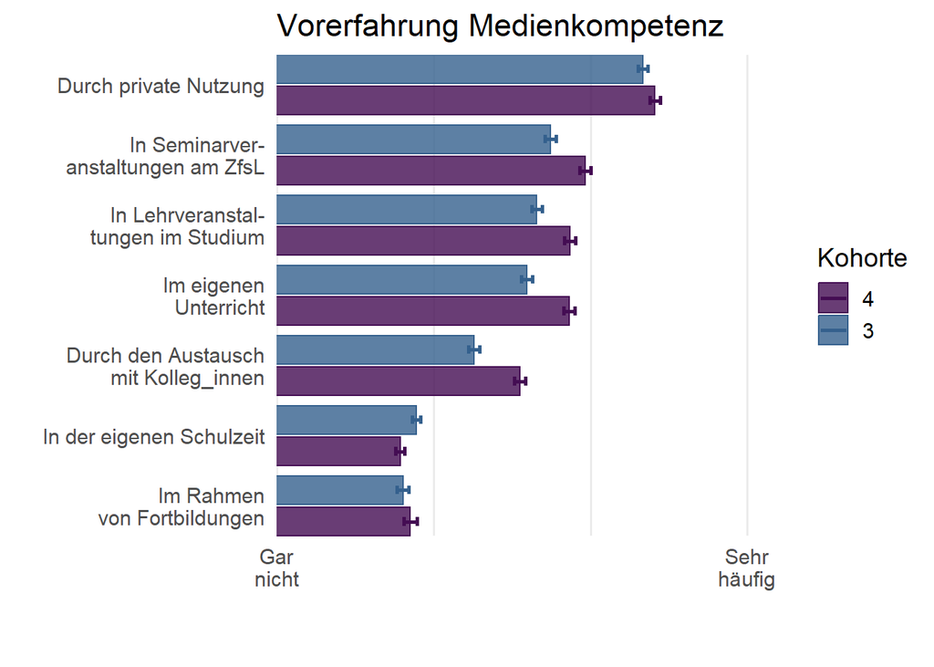

```r
rm(nrw_p)
nrw_p <- nrw |>
  dplyr::filter(kohorte %in% c("3", "4") &
                gruppe %in% c("laa")) |>
  dplyr::select(kohorte, meko_1,
                         meko_2,
                         meko_3,
                         meko_4,
                         meko_5,
                         meko_6,
                         meko_7) |>
  pivot_longer(2:8, names_to = "variables", values_to = "values")

p1 <- ggplot(nrw_p, aes(x=factor(variables,
                                 levels = c("meko_5",
                                            "meko_1",
                                            "meko_6",
                                            "meko_4",
                                            "meko_2",
                                            "meko_3",
                                            "meko_7")),
                        y = values,
                        fill = factor(kohorte,
                                      levels = c("4", "3")),
                        color = factor(kohorte,
                                      levels = c("4", "3")))) +
  stat_summary(geom = "bar", alpha = .8,
               position = position_dodge2(width = 1)) +
  stat_summary(linewidth = 1, geom = "errorbar",
               width = .25, position = position_dodge(width = .9)) +
  scale_fill_manual(values = c(#"#fce725",
                               #"#37b877",
                               "#440d53",
                               "#34608d")) +
  scale_color_manual(values = c(#"#fce725",
                                #"#37b877",
                                "#440d53",
                                "#34608d")) +
  scale_x_discrete(labels = c("Im Rahmen\nvon Fortbildungen",
                              "In der eigenen Schulzeit",
                              "Durch den Austausch\nmit Kolleg_innen",
                              "Im eigenen\nUnterricht",
                              "In Lehrveranstal-\ntungen im Studium",
                              "In Seminarver-\nanstaltungen am ZfsL",
                              "Durch private Nutzung")) +
  scale_y_continuous(labels = c("Gar\nnicht", "", "", "Sehr\nhäufig")) +
  xlab("") +
  ylab("") +
  labs(title = "Vorerfahrung Medienkompetenz",
       #subtitle = "\"Wie häufig sind Sie bisher im Rahmen der unten \ngenannten Lerngelegenheiten bzw. Tätigkeiten mit \ndem Thema des didaktischen/pädagogischen Einsatzes \nvon digitalen Medien in Berührung gekommen?\"",
       caption = "",
       fill = "Kohorte",
       color = "Kohorte") +
  theme_minimal(base_size = 14) +
  theme(#axis.text.x = element_text(angle = 35, vjust = 1, hjust=1),
        panel.grid.minor.x = element_blank(),
        panel.grid.major.y = element_blank(),
        plot.subtitle=element_text(face="italic")) +
  coord_flip(ylim=c(1,4.2),
             expand = F)

p1
```

**Im Rahmen von Fortbildungen**  
*t-Test*  
K3 vs. K4

```r
t.test(meko_5 ~ kohorte,
       data = nrw |> dplyr::filter(kohorte %in% c("3", "4") &
                                   gruppe %in% c("laa")))
```

```
    Welch Two Sample t-test

data:  meko_5 by kohorte
t = -0.85829, df = 1176.9, p-value = 0.3909
alternative hypothesis: true difference in means between group 3 and group 4 is not equal to 0
95 percent confidence interval:
 -0.15704269  0.06145742
sample estimates:
mean in group 3 mean in group 4
       1.803797        1.851590
```

*Cohen’s d*

```r
cohens_d <- psych::cohen.d(meko_5 ~ kohorte,
                           data = nrw |> dplyr::filter(kohorte %in% c("3", "4") &
                                                       gruppe %in% c("laa")))
cohens_d$cohen.d
```

```
             lower     effect     upper
meko_5 -0.06369444 0.04975859 0.1631912
```

*Overlap*  
in Prozent

```r
2 * pnorm(-abs(cohens_d$cohen.d[1, "effect"]) / 2) * 100
```

```
[1] 98.01512
```

**In der eigenen Schulzeit**  
*t-Test*  
K3 vs. K4

```r
t.test(meko_1 ~ kohorte,
       data = nrw |> dplyr::filter(kohorte %in% c("3", "4") &
                                   gruppe %in% c("laa")))
```

```
    Welch Two Sample t-test

data:  meko_1 by kohorte
t = 2.6079, df = 1223.2, p-value = 0.009222
alternative hypothesis: true difference in means between group 3 and group 4 is not equal to 0
95 percent confidence interval:
 0.02551172 0.18048026
sample estimates:
mean in group 3 mean in group 4
       1.890411        1.787415
```

*Cohen’s d*

```r
cohens_d <- psych::cohen.d(meko_1 ~ kohorte,
                           data = nrw |> dplyr::filter(kohorte %in% c("3", "4") &
                                                       gruppe %in% c("laa")))
cohens_d$cohen.d
```

```
            lower    effect       upper
meko_1 -0.2596857 -0.148298 -0.03684974
```

*Overlap*  
in Prozent

```r
2 * pnorm(-abs(cohens_d$cohen.d[1, "effect"]) / 2) * 100
```

```
[1] 94.08918
```

**Durch den Austausch mit Kolleg_innen**  
*t-Test*  
K3 vs. K4

```r
t.test(meko_6 ~ kohorte,
       data = nrw |> dplyr::filter(kohorte %in% c("3", "4") &
                                   gruppe %in% c("laa")))
```

```
    Welch Two Sample t-test

data:  meko_6 by kohorte
t = -5.7953, df = 1216.7, p-value = 8.678e-09
alternative hypothesis: true difference in means between group 3 and group 4 is not equal to 0
95 percent confidence interval:
 -0.3896586 -0.1925582
sample estimates:
mean in group 3 mean in group 4
       2.258114        2.549223
```

*Cohen’s d*

```r
cohens_d <- psych::cohen.d(meko_6 ~ kohorte,
                           data = nrw |> dplyr::filter(kohorte %in% c("3", "4") &
                                                       gruppe %in% c("laa")))
cohens_d$cohen.d
```

```
           lower    effect     upper
meko_6 0.2182264 0.3311841 0.4440068
```

*Overlap*  
in Prozent

```r
2 * pnorm(-abs(cohens_d$cohen.d[1, "effect"]) / 2) * 100
```

```
[1] 86.8478
```

**Im eigenen Unterricht**  
*t-Test*  
K3 vs. K4

```r
t.test(meko_4 ~ kohorte,
       data = nrw |> dplyr::filter(kohorte %in% c("3", "4") &
                                   gruppe %in% c("laa")))
```

```
    Welch Two Sample t-test

data:  meko_4 by kohorte
t = -5.3382, df = 1235, p-value = 1.116e-07
alternative hypothesis: true difference in means between group 3 and group 4 is not equal to 0
95 percent confidence interval:
 -0.3680278 -0.1702134
sample estimates:
mean in group 3 mean in group 4
       2.593893        2.863014
```

*Cohen’s d*

```r
cohens_d <- psych::cohen.d(meko_4 ~ kohorte,
                           data = nrw |> dplyr::filter(kohorte %in% c("3", "4") &
                                                       gruppe %in% c("laa")))
cohens_d$cohen.d
```

```
           lower    effect     upper
meko_4 0.1905079 0.3027523 0.4148747
```

*Overlap*  
in Prozent

```r
2 * pnorm(-abs(cohens_d$cohen.d[1, "effect"]) / 2) * 100
```

```
[1] 87.9679
```

**In Lehrveranstaltungen im Studium**  
*t-Test*  
K3 vs. K4

```r
t.test(meko_2 ~ kohorte,
       data = nrw |> dplyr::filter(kohorte %in% c("3", "4") &
                                   gruppe %in% c("laa")))
```

```
    Welch Two Sample t-test

data:  meko_2 by kohorte
t = -4.4228, df = 1232.9, p-value = 1.06e-05
alternative hypothesis: true difference in means between group 3 and group 4 is not equal to 0
95 percent confidence interval:
 -0.3058327 -0.1178807
sample estimates:
mean in group 3 mean in group 4
       2.656968        2.868825
```

*Cohen’s d*

```r
cohens_d <- psych::cohen.d(meko_2 ~ kohorte,
                           data = nrw |> dplyr::filter(kohorte %in% c("3", "4") &
                                                       gruppe %in% c("laa")))
cohens_d$cohen.d
```

```
           lower    effect     upper
meko_2 0.1392258 0.2511909 0.3630552
```

*Overlap*  
in Prozent

```r
2 * pnorm(-abs(cohens_d$cohen.d[1, "effect"]) / 2) * 100
```

```
[1] 90.00522
```

**In Seminarveranstaltungen am ZfsL**  
*t-Test*  
K3 vs. K4

```r
t.test(meko_3 ~ kohorte,
       data = nrw |> dplyr::filter(kohorte %in% c("3", "4") &
                                   gruppe %in% c("laa")))
```

```
    Welch Two Sample t-test

data:  meko_3 by kohorte
t = -4.551, df = 1235.9, p-value = 5.867e-06
alternative hypothesis: true difference in means between group 3 and group 4 is not equal to 0
95 percent confidence interval:
 -0.3181328 -0.1264682
sample estimates:
mean in group 3 mean in group 4
       2.743511        2.965812
```

*Cohen’s d*

```r
cohens_d <- psych::cohen.d(meko_3 ~ kohorte,
                           data = nrw |> dplyr::filter(kohorte %in% c("3", "4") &
                                                       gruppe %in% c("laa")))
cohens_d$cohen.d
```

```
           lower    effect    upper
meko_3 0.1460397 0.2580501 0.369957
```

*Overlap*  
in Prozent

```r
2 * pnorm(-abs(cohens_d$cohen.d[1, "effect"]) / 2) * 100
```

```
[1] 89.73378
```

**Durch private Nutzung**  
*t-Test*  
K3 vs. K4

```r
t.test(meko_7 ~ kohorte,
       data = nrw |> dplyr::filter(kohorte %in% c("3", "4") &
                                   gruppe %in% c("laa")))
```

```
    Welch Two Sample t-test

data:  meko_7 by kohorte
t = -1.718, df = 1220.8, p-value = 0.08606
alternative hypothesis: true difference in means between group 3 and group 4 is not equal to 0
95 percent confidence interval:
 -0.16761132  0.01111177
sample estimates:
mean in group 3 mean in group 4
       3.332312        3.410562
```

*Cohen’s d*

```r
cohens_d <- psych::cohen.d(meko_7 ~ kohorte,
                           data = nrw |> dplyr::filter(kohorte %in% c("3", "4") &
                                                       gruppe %in% c("laa")))
cohens_d$cohen.d
```

```
             lower     effect     upper
meko_7 -0.01371021 0.09785275 0.2093761
```

*Overlap*  
in Prozent

```r
2 * pnorm(-abs(cohens_d$cohen.d[1, "effect"]) / 2) * 100
```

```
[1] 96.0978
```

#### 3.1.3.2 Selbsteinschätzung Medienkompetenz

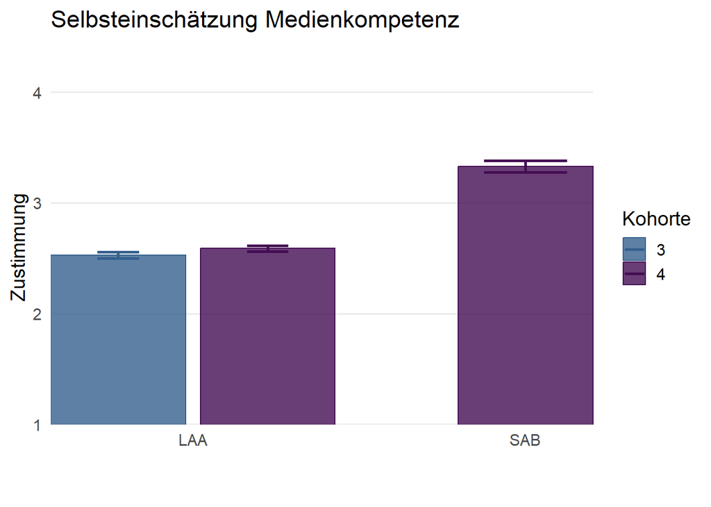

```r
rm(nrw_p)
nrw_p <- nrw |>
  dplyr::filter(kohorte %in% c("3", "4") & gruppe %in% c("laa", "sab"))

p1 <- ggplot(nrw_p, aes(x=gruppe,
                        y = mekos,
                        fill = kohorte,
                        color = kohorte)) +
  stat_summary(geom = "bar", alpha = .8,
               position = position_dodge2(width = 1, preserve = "single")) +
  stat_summary(linewidth = 1, geom = "errorbar",
               width = .25, position = position_dodge(width = .9)) +
  scale_fill_manual(values = c(#"#fce725",
                               #"#37b877",
                               "#34608d",
                               "#440d53")) +
  scale_color_manual(values = c(#"#fce725",
                                #"#37b877",
                                "#34608d",
                                "#440d53")) +
  scale_x_discrete(labels = c("LAA",
                              "SAB")) +
  xlab("") +
  ylab("Zustimmung") +
  labs(title = "Selbsteinschätzung Medienkompetenz",
       subtitle = "",
       caption = "",
       fill = "Kohorte",
       color = "Kohorte") +
  theme_minimal(base_size = 14) +
  theme(panel.grid.major.x = element_blank(),
        panel.grid.minor.y = element_blank(),
        plot.subtitle=element_text(face="italic")) +
  coord_cartesian(ylim=c(1,4.2),
                  expand = F)

p1
```

**LAA: Selbsteinschätzung Medienkompetenz**  
*t-Test*  
K3 vs. K4

```r
t.test(mekos ~ kohorte,
       data = nrw |> dplyr::filter(kohorte %in% c("3", "4") &
                                   gruppe %in% c("laa")))
```

```
    Welch Two Sample t-test

data:  mekos by kohorte
t = -1.5813, df = 1231.5, p-value = 0.1141
alternative hypothesis: true difference in means between group 3 and group 4 is not equal to 0
95 percent confidence interval:
 -0.13745149  0.01476362
sample estimates:
mean in group 3 mean in group 4
       2.526641        2.587985
```

*Cohen’s d*

```r
cohens_d <- psych::cohen.d(mekos ~ kohorte,
                           data = nrw |> dplyr::filter(kohorte %in% c("3", "4") &
                                                       gruppe %in% c("laa")))
cohens_d$cohen.d
```

```
            lower     effect     upper
mekos -0.02180005 0.08982088 0.2014056
```

*Overlap*  
in Prozent

```r
2 * pnorm(-abs(cohens_d$cohen.d[1, "effect"]) / 2) * 100
```

```
[1] 96.41787
```

**LAA vs. SAB: Selbsteinschätzung Medienkompetenz**  
*t-Test*

```r
t.test(mekos ~ gruppe,
       data = nrw |> dplyr::filter(kohorte %in% c("4") &
                                   gruppe %in% c("laa", "sab")))
```

```
    Welch Two Sample t-test

data:  mekos by gruppe
t = -12.893, df = 301.88, p-value < 2.2e-16
alternative hypothesis: true difference in means between group laa and group sab is not equal to 0
95 percent confidence interval:
 -0.8537144 -0.6276125
sample estimates:
mean in group laa mean in group sab
         2.587985          3.328649
```

*Cohen’s d*

```r
cohens_d <- psych::cohen.d(mekos ~ gruppe,
                           data = nrw |> dplyr::filter(kohorte %in% c("4") &
                                                       gruppe %in% c("laa", "sab")))
cohens_d$cohen.d
```

```
          lower   effect    upper
mekos 0.9310742 1.105766 1.279807
```

*Overlap*  
in Prozent

```r
2 * pnorm(-abs(cohens_d$cohen.d[1, "effect"]) / 2) * 100
```

```
[1] 58.03435
```

### 3.1.4 TPK

#### 3.1.4.1 Reliabilität

In https://doi.org/10.1016/j.compedu.2019.103645 finden sich keine Angaben zur Reliabilität, deshalb berechnen wir McDonald’s Omega.

**Die einzelnen Items des TPK-Tests sind nicht im Datensatz enthalten, deshalb kann ich keine interne Konsistenz berechnen.**

#### 3.1.4.2 TPK Test

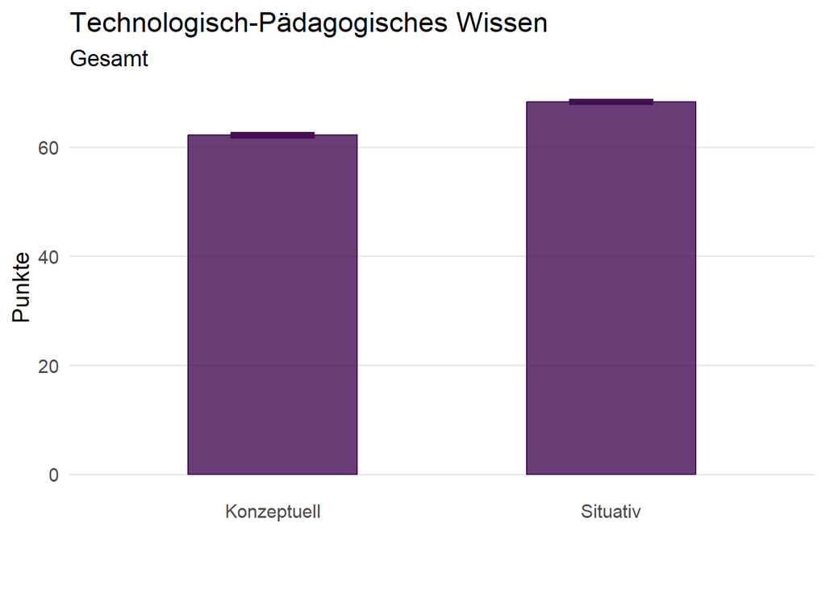

```r
nrw_p <- nrw |>
  dplyr::select(kohorte, gruppe, tpkcon_score, tpksit_score) |>
  dplyr::filter(kohorte %in% c("4") & gruppe %in% c("laa")) |>
  pivot_longer(3:4, names_to = "variables", values_to = "values")

p1 <- ggplot(nrw_p, aes(x=variables, y = values, fill = kohorte, color = kohorte)) +
  stat_summary(geom = "bar", alpha = .8, width = .5,
               position = position_dodge2(width = 1, preserve = "single")) +
  stat_summary(linewidth = 1, geom = "errorbar",
               width = .25, position = position_dodge(width = .9)) +
  scale_x_discrete(labels = c("Konzeptuell", "Situativ")) +
  scale_fill_manual(values = c(#"#fce725",
                               #"#37b877",
                               #"#34608d",
                               "#440d53")) +
  scale_color_manual(values = c(#"#fce725",
                               #"#37b877",
                               #"#34608d",
                               "#440d53")) +
  xlab("") +
  ylab("Punkte") +
  labs(title = "Technologisch-Pädagogisches Wissen",
       subtitle = "Gesamt",
       caption = "",
       fill = "Kohorte",
       color = "Kohorte") +
  theme_minimal(base_size = 14) +
  theme(panel.grid.major.x = element_blank(),
        panel.grid.minor.y = element_blank(),
        legend.position = "none")

p1
```

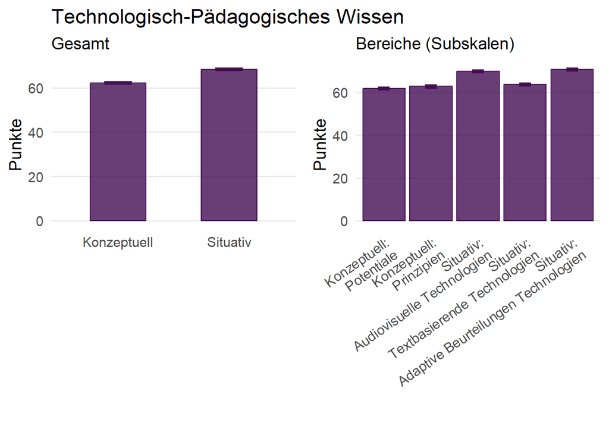

```r
rm(nrw_p)
nrw_p <- nrw |>
  dplyr::select(kohorte, gruppe,
                tpkpot_score,
                tpksup_score,
                tpksit_score_av,
                tpksit_score_tb,
                tpksit_score_aa) |>
  dplyr::filter(kohorte %in% c("4") & gruppe %in% c("laa")) |>
  pivot_longer(3:7, names_to = "variables", values_to = "values")

p2 <- ggplot(nrw_p, aes(x=factor(variables,
                                 levels = c("tpkpot_score",
                                            "tpksup_score",
                                            "tpksit_score_av",
                                            "tpksit_score_tb",
                                            "tpksit_score_aa")),
                        y = values, fill = kohorte, color = kohorte)) +
  stat_summary(geom = "bar", alpha = .8,
               position = position_dodge2(width = 1, preserve = "single")) +
  stat_summary(linewidth = 1, geom = "errorbar",
               width = .25, position = position_dodge(width = .9)) +
  scale_fill_manual(values = c(#"#fce725",
                               #"#37b877",
                               #"#34608d",
                               "#440d53")) +
  scale_color_manual(values = c(#"#fce725",
                               #"#37b877",
                               #"#34608d",
                               "#440d53")) +
  scale_x_discrete(labels = c("Konzeptuell:\nPotentiale",
                              "Konzeptuell:\nPrinzipien",
                              "Situativ:\nAudiovisuelle Technologien",
                              "Situativ:\nTextbasierende Technologien",
                              "Situativ:\nAdaptive Beurteilungen Technologien")) +
  xlab("") +
  ylab("Punkte") +
  labs(title = "Technologisch-Pädagogisches Wissen",
       subtitle = "Bereiche (Subskalen)",
       caption = "",
       fill = "Kohorte",
       color = "Kohorte") +
  theme_minimal(base_size = 14) +
  theme(axis.text.x = element_text(angle = 35, vjust = 1, hjust=1),
        panel.grid.major.x = element_blank(),
        panel.grid.minor.y = element_blank())

ggarrange(p1, p2 + labs(title = ""),
          ncol = 2,
          align = "hv",
          common.legend = T,
          legend = "none")
```

#### 3.1.4.3 Korrelation TPK ~~ Selbstberichte

Der LAA in Kohorte 4.

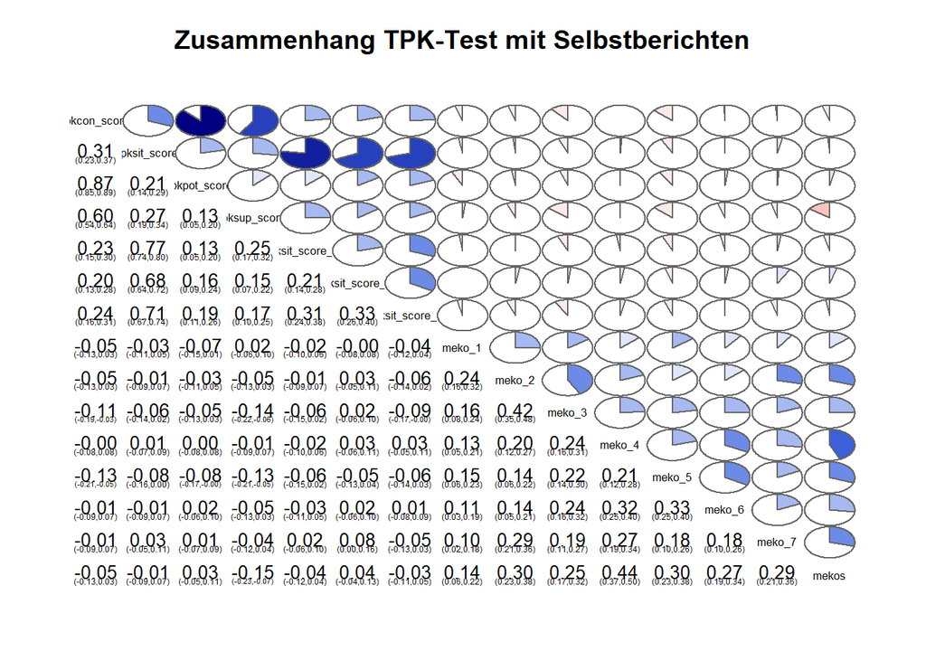

```r
rm(nrw_p)
nrw_p <- nrw |>
  dplyr::filter(kohorte %in% c("4") & gruppe %in% c("laa")) |>
  dplyr::select(tpkcon_score,
                tpksit_score,
                tpkpot_score,
                tpksup_score,
                tpksit_score_av,
                tpksit_score_tb,
                tpksit_score_aa,
                meko_1,
                meko_2,
                meko_3,
                meko_4,
                meko_5,
                meko_6,
                meko_7,
                mekos
                )


corrgram(nrw_p,
         upper.panel=panel.pie,
         lower.panel=panel.conf,
         text.panel=panel.txt,
         main="Zusammenhang TPK-Test mit Selbstberichten")
```

## 3.2 Der VD aus Sicht der LAA

Anforderungsbewältigung der LAA: Umgang mit herausfordernden Situationen: Stress Resilienz (Wie empfinden die beteiligten Personen ihre Arbeit? Hölle Referendariat (Zum Teil schon berichtet, Oktober 2023)

### 3.2.1 Anforderungsbewältigung

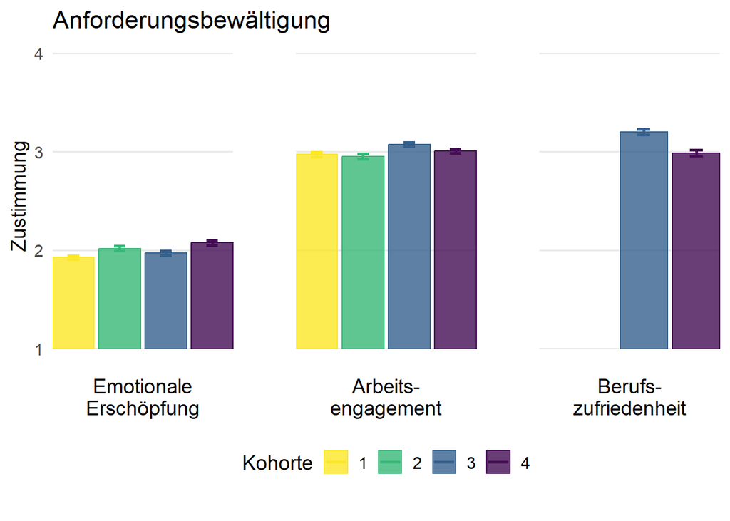

```r
rm(nrw_p)
nrw_p <- nrw |>
  dplyr::filter(gruppe %in% c("laa"))

p1 <- ggplot(nrw_p, aes(x=factor(kohorte,
                                 levels = c("1", "2", "3", "4")),
                        y = bel, fill = kohorte, color = kohorte)) +
  stat_summary(geom = "bar", alpha = .8,
               position = position_dodge2(width = 1, preserve = "single")) +
  stat_summary(linewidth = 1, geom = "errorbar",
               width = .25, position = position_dodge(width = .9)) +
  scale_fill_manual(values = c("#fce725",
                               "#37b877",
                               "#34608d",
                               "#440d53"),
                    drop = F) +
  scale_color_manual(values = c("#fce725",
                                "#37b877",
                                "#34608d",
                                "#440d53"),
                    drop = F) +
  scale_x_discrete(breaks = c(1:4),
                   labels = c("", "", "", "")) +
  coord_cartesian(ylim = c(1,4.1),
                  expand = F) +
  xlab("") +
  ylab("Zustimmung") +
  labs(title = "Emotionale Erschöpfung",
       # subtitle = "Bereiche (Subskalen)",
       caption = "",
       fill = "Kohorte",
       color = "Kohorte") +
  theme_minimal(base_size = 14) +
  theme(#axis.text.x = element_text(angle = 35, vjust = 1, hjust=1),
        panel.grid.major.x = element_blank(),
        panel.grid.minor.y = element_blank())

p2 <- ggplot(nrw_p, aes(x=kohorte,
                        y = aen, fill = kohorte, color = kohorte)) +
  stat_summary(geom = "bar", alpha = .8,
               position = position_dodge2(width = 1, preserve = "single")) +
  stat_summary(linewidth = 1, geom = "errorbar",
               width = .25, position = position_dodge(width = .9)) +
  scale_fill_manual(values = c("#fce725",
                               "#37b877",
                               "#34608d",
                               "#440d53")) +
  scale_color_manual(values = c("#fce725",
                                "#37b877",
                                "#34608d",
                                "#440d53")) +
  scale_x_discrete(breaks = c(1:4),
                   labels = c("", "", "", "")) +
  coord_cartesian(ylim = c(1,4.1),
                  expand = F) +
  xlab("") +
  ylab("Zustimmung") +
  labs(title = "Arbeitsengagement",
       # subtitle = "Bereiche (Subskalen)",
       caption = "",
       fill = "Kohorte",
       color = "Kohorte") +
  theme_minimal(base_size = 14) +
  theme(#axis.text.x = element_text(angle = 35, vjust = 1, hjust=1),
        panel.grid.major.x = element_blank(),
        panel.grid.minor.y = element_blank())

p3 <- ggplot(nrw_p, aes(x=kohorte,
                        y = zfr, fill = kohorte, color = kohorte)) +
  stat_summary(geom = "bar", alpha = .8,
               position = position_dodge2(width = 1, preserve = "single")) +
  stat_summary(linewidth = 1, geom = "errorbar",
               width = .25, position = position_dodge(width = .9)) +
  scale_fill_manual(values = c(#"#fce725",
                               #"#37b877",
                               "#34608d",
                               "#440d53")) +
  scale_color_manual(values = c(#"#fce725",
                                #"#37b877",
                                "#34608d",
                                "#440d53")) +
  scale_x_discrete(breaks = c(3:4),
                   labels = c("", "")) +
  coord_cartesian(ylim = c(1,4.1),
                  expand = F) +
  xlab("") +
  ylab("Zustimmung") +
  labs(title = "Berufszufriedenheit",
       caption = "",
       fill = "Kohorte",
       color = "Kohorte") +
  theme_minimal(base_size = 14) +
  theme(#axis.text.x = element_text(angle = 35, vjust = 1, hjust=1),
        panel.grid.major.x = element_blank(),
        panel.grid.minor.y = element_blank())

ggarrange(p1 +
            xlab("Emotionale\nErschöpfung") +
            labs(title = "Anforderungsbewältigung") +
            theme(legend.position = "none"),
          p2 + xlab("Arbeits-\nengagement") + ylab("") + labs(title = "") +
            theme(legend.position = "bottom",
                  axis.text.y = element_blank()),
          p3 +
            xlab("Berufs-\nzufriedenheit") +
            ylab("") +
            labs(title = "") +
            # scale_x_discrete(limits = c(1,4),
            #                  breaks = c(1:4),
            #        labels = c("", "", "", "")) +
            theme(legend.position = "none",
                  axis.text.y = element_blank()),
          align = "hv",
          ncol = 3)
```

#### 3.2.1.1 Emotionale Erschöpfung

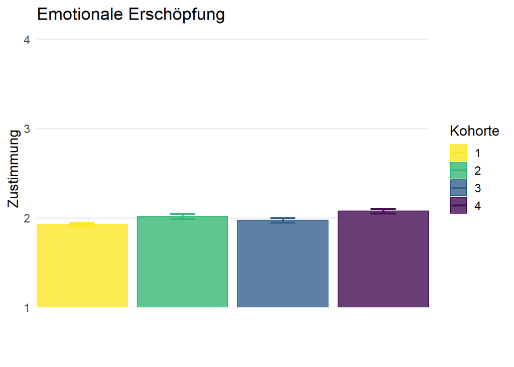

```r
p1
```

**Über die Zeit**

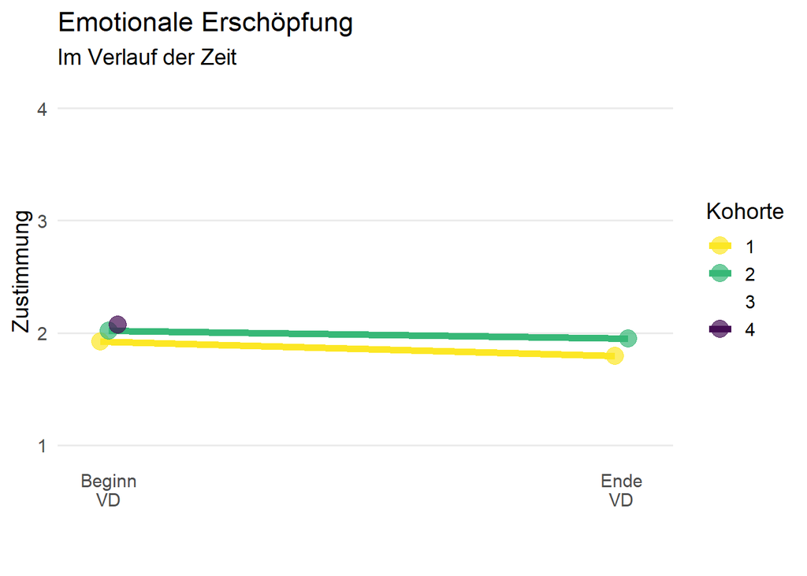

```r
rm(nrw_p)
nrw_p <- nrw |>
  dplyr::filter(kohorte %in% c("1", "2", "4") & gruppe %in% c("laa")) |>
  dplyr::select(kohorte, bel, ee_3) |>
  pivot_longer(2:3, names_to = "variables", values_to = "values")

p1a <- ggplot(nrw_p, aes(x=variables,
                        y = values,
                        fill = kohorte,
                        color = kohorte,
                        group = kohorte)) +
  stat_summary(linewidth = 2, geom = "line",
               position = position_dodge(width = .05)) +
  stat_summary(geom = "point", size = 5,
               position = position_dodge(width = .05),
               alpha = .7) +
  scale_fill_manual(values = c("#fce725",
                               "#37b877",
                               "#34608d",
                               "#440d53"),
                    drop = F) +
  scale_color_manual(values = c("#fce725",
                                "#37b877",
                                "#34608d",
                                "#440d53"),
                    drop = F) +
  coord_cartesian(ylim = c(1,4.1)) +
  scale_x_discrete(labels = c("Beginn\nVD", "Ende\nVD"),
                   expand = expansion(mult = c(.1, .1))) +
  xlab("") +
  ylab("Zustimmung") +
  labs(title = "Emotionale Erschöpfung",
       subtitle = "Im Verlauf der Zeit",
       caption = "",
       fill = "Kohorte",
       color = "Kohorte") +
  theme_minimal(base_size = 14) +
  theme(panel.grid.major.x = element_blank(),
        panel.grid.minor.y = element_blank())

p1a
```

**Emotionale Erschöpfung**  
*ANOVA*  
K1 vs. K2 vs. K3 vs. K4  
zu MZP 1

```r
fit_aov <- aov(scale(bel) ~ kohorte,
               data = nrw |> dplyr::filter(gruppe %in% c("laa")))
summary(fit_aov)
```

```
              Df Sum Sq Mean Sq F value   Pr(>F)
kohorte        3   26.8   8.925   9.004 6.23e-06 ***
Residuals   2709 2685.2   0.991
---
Signif. codes:  0 '***' 0.001 '**' 0.01 '*' 0.05 '.' 0.1 ' ' 1
2671 Beobachtungen als fehlend gelöscht
```

*Kontraste*  
p-Werte adjustiert nach Tukey.  
Werte unter “estimate” sind Cohen’d äquivalent zu interpretieren.

```r
pairs(lsmeans(fit_aov, ~ kohorte))
```

```
 contrast            estimate     SE   df t.ratio p.value
 kohorte1 - kohorte2  -0.1590 0.0556 2709  -2.861  0.0221
 kohorte1 - kohorte3  -0.0809 0.0500 2709  -1.617  0.3691
 kohorte1 - kohorte4  -0.2596 0.0518 2709  -5.009  <.0001
 kohorte2 - kohorte3   0.0780 0.0603 2709   1.294  0.5668
 kohorte2 - kohorte4  -0.1007 0.0618 2709  -1.629  0.3622
 kohorte3 - kohorte4  -0.1787 0.0569 2709  -3.141  0.0092

Note: contrasts are still on the scale(1.98, 0.58) scale
P value adjustment: tukey method for comparing a family of 4 estimates
```

**Emotionale Erschöpfung**  
*t-Test*  
K1: MZP1 vs. MZP3

```r
nrw_p <- nrw |>
  dplyr::filter(kohorte %in% c("1") &
                gruppe %in% c("laa"))

t.test(nrw_p$bel,
       nrw_p$ee_3,
       paired = T)
```

```
    Paired t-test

data:  nrw_p$bel and nrw_p$ee_3
t = 1.4968, df = 65, p-value = 0.1393
alternative hypothesis: true mean difference is not equal to 0
95 percent confidence interval:
 -0.03925145  0.27409994
sample estimates:
mean difference
      0.1174242
```

*Cohen’s d*

```r
cohens_d <- effsize::cohen.d(nrw_p$bel, nrw_p$ee_3,
                             paired = TRUE,
                             na.rm = TRUE)

cohens_d
```

```
Cohen's d

d estimate: 0.1917993 (negligible)
95 percent confidence interval:
      lower       upper
-0.06403008  0.44762864
```

*Overlap*  
in Prozent

```r
2 * pnorm(-abs(cohens_d$estimate) / 2) * 100
```

```
[1] 92.36003
```

**Emotionale Erschöpfung**  
*t-Test*  
K2: MZP1 vs. MZP3

```r
nrw_p <- nrw |>
  dplyr::filter(kohorte %in% c("2") &
                gruppe %in% c("laa"))

t.test(nrw_p$bel,
       nrw_p$ee_3,
       paired = T)
```

```
    Paired t-test

data:  nrw_p$bel and nrw_p$ee_3
t = 2.1353, df = 319, p-value = 0.0335
alternative hypothesis: true mean difference is not equal to 0
95 percent confidence interval:
 0.005793288 0.141602546
sample estimates:
mean difference
     0.07369792
```

*Cohen’s d*

```r
cohens_d <- effsize::cohen.d(nrw_p$bel, nrw_p$ee_3,
                             paired = TRUE,
                             na.rm = TRUE)

cohens_d
```

```
Cohen's d

d estimate: 0.1220362 (negligible)
95 percent confidence interval:
      lower       upper
0.009389716 0.234682734
```

*Overlap*  
in Prozent

```r
2 * pnorm(-abs(cohens_d$estimate) / 2) * 100
```

```
[1] 95.13448
```

#### 3.2.1.2 Arbeitsengagement

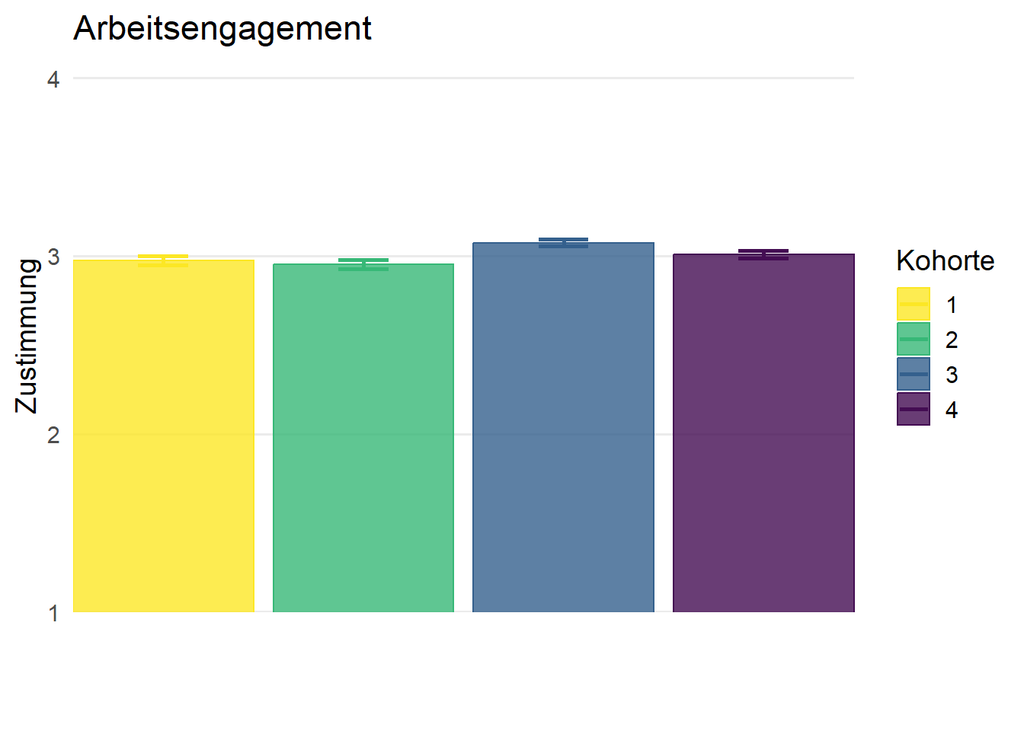

```r
p2
```

**Über die Zeit**

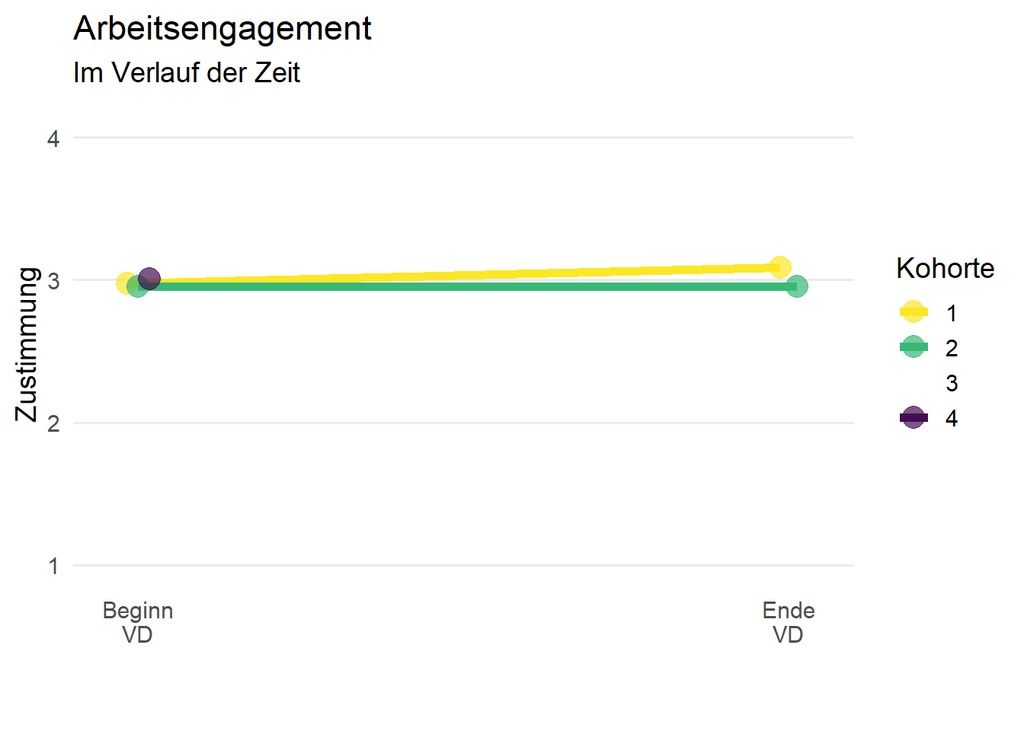

```r
rm(nrw_p)
nrw_p <- nrw |>
  dplyr::filter(kohorte %in% c("1", "2", "4") & gruppe %in% c("laa")) |>
  dplyr::select(kohorte, aen, aen_3) |>
  pivot_longer(2:3, names_to = "variables", values_to = "values")

p2a <- ggplot(nrw_p, aes(x=variables,
                        y = values,
                        fill = kohorte,
                        color = kohorte,
                        group = kohorte)) +
  stat_summary(linewidth = 2, geom = "line",
               position = position_dodge(width = .05)) +
  stat_summary(geom = "point", size = 5,
               position = position_dodge(width = .05),
               alpha = .7) +
  scale_fill_manual(values = c("#fce725",
                               "#37b877",
                               "#34608d",
                               "#440d53"),
                    drop = F) +
  scale_color_manual(values = c("#fce725",
                                "#37b877",
                                "#34608d",
                                "#440d53"),
                    drop = F) +
  coord_cartesian(ylim = c(1,4.1)) +
  scale_x_discrete(labels = c("Beginn\nVD", "Ende\nVD"),
                   expand = expansion(mult = c(.1, .1))) +
  xlab("") +
  ylab("Zustimmung") +
  labs(title = "Arbeitsengagement",
       subtitle = "Im Verlauf der Zeit",
       caption = "",
       fill = "Kohorte",
       color = "Kohorte") +
  theme_minimal(base_size = 14) +
  theme(panel.grid.major.x = element_blank(),
        panel.grid.minor.y = element_blank())

p2a
```

**Arbeitsengagement**  
*ANOVA*  
K1 vs. K2 vs. K3 vs. K4  
zu MZP 1

```r
fit_aov <- aov(scale(aen) ~ kohorte,
               data = nrw |> dplyr::filter(gruppe %in% c("laa")))
summary(fit_aov)
```

```
              Df Sum Sq Mean Sq F value   Pr(>F)
kohorte        3   16.8   5.611   5.647 0.000748 ***
Residuals   2206 2192.2   0.994
---
Signif. codes:  0 '***' 0.001 '**' 0.01 '*' 0.05 '.' 0.1 ' ' 1
3174 Beobachtungen als fehlend gelöscht
```

*Kontraste*  
p-Werte adjustiert nach Tukey.  
Werte unter “estimate” sind Cohen’d äquivalent zu interpretieren.

```r
pairs(lsmeans(fit_aov, ~ kohorte))
```

```
 contrast            estimate     SE   df t.ratio p.value
 kohorte1 - kohorte2   0.0381 0.0636 2206   0.599  0.9324
 kohorte1 - kohorte3  -0.1865 0.0596 2206  -3.130  0.0096
 kohorte1 - kohorte4  -0.0636 0.0611 2206  -1.041  0.7254
 kohorte2 - kohorte3  -0.2246 0.0597 2206  -3.762  0.0010
 kohorte2 - kohorte4  -0.1016 0.0612 2206  -1.662  0.3444
 kohorte3 - kohorte4   0.1230 0.0570 2206   2.157  0.1357

Note: contrasts are still on the scale(3.01, 0.539) scale
P value adjustment: tukey method for comparing a family of 4 estimates
```

**Arbeitsengagement**  
*t-Test*  
K1: MZP1 vs. MZP3

```r
nrw_p <- nrw |>
  dplyr::filter(kohorte %in% c("1") &
                gruppe %in% c("laa"))

t.test(nrw_p$aen,
       nrw_p$aen_3,
       paired = T)
```

```
    Paired t-test

data:  nrw_p$aen and nrw_p$aen_3
t = -0.48684, df = 33, p-value = 0.6296
alternative hypothesis: true mean difference is not equal to 0
95 percent confidence interval:
 -0.2596750  0.1593949
sample estimates:
mean difference
    -0.05014006
```

*Cohen’s d*

```r
cohens_d <- effsize::cohen.d(nrw_p$aen, nrw_p$aen_3,
                             paired = TRUE,
                             na.rm = TRUE)

cohens_d
```

```
Cohen's d

d estimate: -0.07058448 (negligible)
95 percent confidence interval:
     lower      upper
-0.3604145  0.2192456
```

*Overlap*  
in Prozent

```r
2 * pnorm(-abs(cohens_d$estimate) / 2) * 100
```

```
[1] 97.18467
```

**Arbeitsengagement**  
*t-Test*  
K2: MZP1 vs. MZP3

```r
nrw_p <- nrw |>
  dplyr::filter(kohorte %in% c("2") &
                gruppe %in% c("laa"))

t.test(nrw_p$aen,
       nrw_p$aen_3,
       paired = T)
```

```
    Paired t-test

data:  nrw_p$aen and nrw_p$aen_3
t = 0.10144, df = 331, p-value = 0.9193
alternative hypothesis: true mean difference is not equal to 0
95 percent confidence interval:
 -0.06059808  0.06718770
sample estimates:
mean difference
    0.003294812
```

*Cohen’s d*

```r
cohens_d <- effsize::cohen.d(nrw_p$aen, nrw_p$aen_3,
                             paired = TRUE,
                             na.rm = TRUE)

cohens_d
```

```
Cohen's d

d estimate: 0.005597879 (negligible)
95 percent confidence interval:
     lower      upper
-0.1027580  0.1139538
```

*Overlap*  
in Prozent

```r
2 * pnorm(-abs(cohens_d$estimate) / 2) * 100
```

```
[1] 99.77668
```

#### 3.2.1.3 Berufszufriedenheit

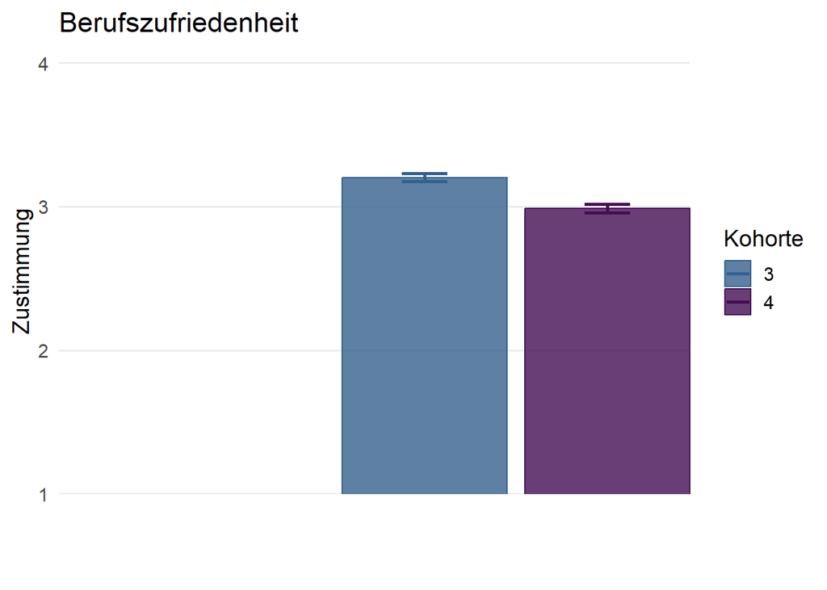

```r
p3
```

### 3.2.2 Bild der eigenen Tätigkeit

#### 3.2.2.1 Zielorientierung als Lehrkraft

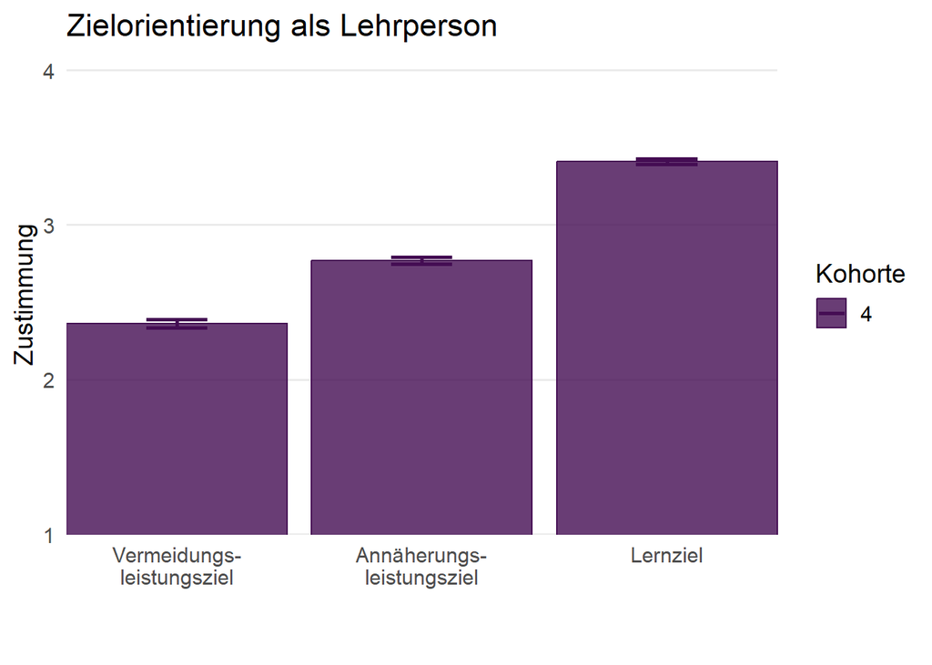

```r
rm(nrw_p)
nrw_p <- nrw |>
  dplyr::filter(gruppe %in% c("laa")) |>
  dplyr::select(kohorte, palk,
                         palaz,
                         palvz) |>
  pivot_longer(2:4, names_to = "variables", values_to = "values")


p1 <- ggplot(nrw_p, aes(x=factor(variables,
                                 levels = c("palvz", "palaz", "palk")),
                        y = values,
                        fill = kohorte, color = kohorte)) +
  stat_summary(geom = "bar", alpha = .8,
               position = position_dodge2(width = 1, preserve = "single")) +
  stat_summary(linewidth = 1, geom = "errorbar",
               width = .25, position = position_dodge(width = .9)) +
  scale_fill_manual(values = c(#"#fce725",
                               #"#37b877",
                               #"#34608d",
                               "#440d53")) +
  scale_color_manual(values = c(#"#fce725",
                                #"#37b877",
                                #"#34608d",
                                "#440d53")) +
  scale_x_discrete(labels = c("Vermeidungs-\nleistungsziel",
                              "Annäherungs-\nleistungsziel",
                              "Lernziel")) +
  coord_cartesian(ylim = c(1,4.1),
                  expand = F) +
  xlab("") +
  ylab("Zustimmung") +
  labs(title = "Zielorientierung als Lehrperson",
       # subtitle = "Bereiche (Subskalen)",
       caption = "",
       fill = "Kohorte",
       color = "Kohorte") +
  theme_minimal(base_size = 14) +
  theme(panel.grid.major.x = element_blank(),
        panel.grid.minor.y = element_blank())

p1
```

#### 3.2.2.2 Überzeugungen über das Lernen

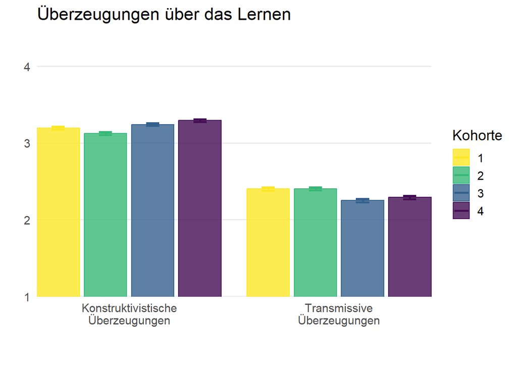

```r
rm(nrw_p)
nrw_p <- nrw |>
  dplyr::select(kohorte, gruppe,
                uebr, uebk) |>
  dplyr::filter(gruppe %in% c("laa")) |>
  pivot_longer(3:4, names_to = "variables", values_to = "values")

p1 <- ggplot(nrw_p, aes(x=variables,
                        y = values,
                        fill = kohorte,
                        color = kohorte)) +
  stat_summary(geom = "bar", alpha = .8,
               position = position_dodge2(width = 1)) +
  stat_summary(linewidth = 1, geom = "errorbar",
               width = .25, position = position_dodge(width = .9)) +
  scale_fill_manual(values = c("#fce725",
                               "#37b877",
                               "#34608d",
                               "#440d53")) +
  scale_color_manual(values = c("#fce725",
                                "#37b877",
                                "#34608d",
                                "#440d53")) +
  scale_x_discrete(labels = c("Konstruktivistische\nÜberzeugungen",
                              "Transmissive\nÜberzeugungen")) +
  coord_cartesian(ylim=c(1,4.2),
                  expand = F) +
  xlab("") +
  ylab("") +
  labs(title = "Überzeugungen über das Lernen",
       subtitle = "",
       caption = "",
       fill = "Kohorte",
       color = "Kohorte") +
  theme_minimal(base_size = 14) +
  theme(panel.grid.major.x = element_blank(),
        panel.grid.minor.y = element_blank())

p1
```

**Konstruktivistische Überzeugungen** *ANOVA* K1 vs. K2 vs. K3 vs. K4

```r
fit_aov <- aov(scale(uebk) ~ kohorte,
               data = nrw |> dplyr::filter(gruppe %in% c("laa")))
summary(fit_aov)
```

```
              Df Sum Sq Mean Sq F value   Pr(>F)
kohorte        3   42.6  14.211   14.46 2.48e-09 ***
Residuals   2292 2252.4   0.983
---
Signif. codes:  0 '***' 0.001 '**' 0.01 '*' 0.05 '.' 0.1 ' ' 1
3088 Beobachtungen als fehlend gelöscht
```

*Kontraste*  
p-Werte adjustiert nach Tukey.  
Werte unter “estimate” sind Cohen’d äquivalent zu interpretieren.

```r
pairs(lsmeans(fit_aov, ~ kohorte))
```

```
 contrast            estimate     SE   df t.ratio p.value
 kohorte1 - kohorte2    0.159 0.0623 2292   2.546  0.0534
 kohorte1 - kohorte3   -0.102 0.0584 2292  -1.748  0.2990
 kohorte1 - kohorte4   -0.219 0.0591 2292  -3.702  0.0013
 kohorte2 - kohorte3   -0.261 0.0587 2292  -4.438  0.0001
 kohorte2 - kohorte4   -0.377 0.0595 2292  -6.348  <.0001
 kohorte3 - kohorte4   -0.117 0.0554 2292  -2.109  0.1506

Note: contrasts are still on the scale(3.22, 0.448) scale
P value adjustment: tukey method for comparing a family of 4 estimates
```

**Transmissive Überzeugungen** *ANOVA* K1 vs. K2 vs. K3 vs. K4

```r
fit_aov <- aov(scale(uebr) ~ kohorte,
               data = nrw |> dplyr::filter(gruppe %in% c("laa")))
summary(fit_aov)
```

```
              Df Sum Sq Mean Sq F value   Pr(>F)
kohorte        3   36.1  12.030   12.21 6.35e-08 ***
Residuals   2278 2244.9   0.985
---
Signif. codes:  0 '***' 0.001 '**' 0.01 '*' 0.05 '.' 0.1 ' ' 1
3102 Beobachtungen als fehlend gelöscht
```

*Kontraste*  
p-Werte adjustiert nach Tukey.  
Werte unter “estimate” sind Cohen’d äquivalent zu interpretieren.

```r
pairs(lsmeans(fit_aov, ~ kohorte))
```

```
 contrast            estimate     SE   df t.ratio p.value
 kohorte1 - kohorte2 -0.00155 0.0628 2278  -0.025  1.0000
 kohorte1 - kohorte3  0.28320 0.0587 2278   4.827  <.0001
 kohorte1 - kohorte4  0.20672 0.0594 2278   3.481  0.0029
 kohorte2 - kohorte3  0.28475 0.0591 2278   4.818  <.0001
 kohorte2 - kohorte4  0.20827 0.0598 2278   3.482  0.0028
 kohorte3 - kohorte4 -0.07648 0.0555 2278  -1.378  0.5132

Note: contrasts are still on the scale(2.33, 0.532) scale
P value adjustment: tukey method for comparing a family of 4 estimates
```

## 3.3 Beurteilung der aktuellen Ausbildungssituation im VD

### 3.3.1 TPK

Der SAB

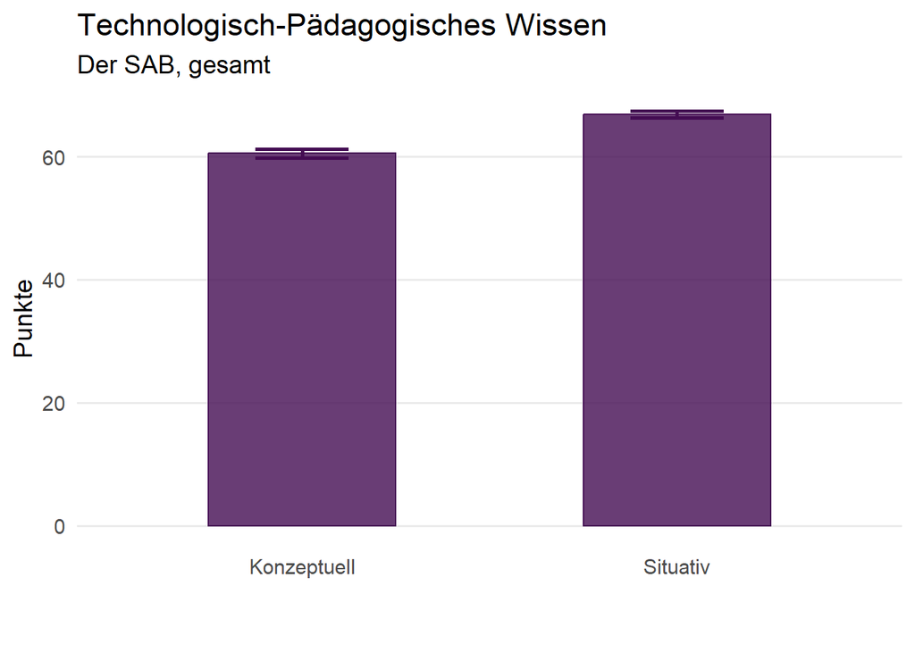

```r
nrw_p <- nrw |>
  dplyr::select(kohorte, gruppe, tpkcon_score, tpksit_score) |>
  dplyr::filter(kohorte %in% c("4") & gruppe %in% c("sab")) |>
  pivot_longer(3:4, names_to = "variables", values_to = "values")

p1 <- ggplot(nrw_p, aes(x=variables, y = values, fill = kohorte, color = kohorte)) +
  stat_summary(geom = "bar", alpha = .8, width = .5,
               position = position_dodge2(width = 1, preserve = "single")) +
  stat_summary(linewidth = 1, geom = "errorbar",
               width = .25, position = position_dodge(width = .9)) +
  scale_x_discrete(labels = c("Konzeptuell", "Situativ")) +
  scale_fill_manual(values = c(#"#fce725",
                               #"#37b877",
                               #"#34608d",
                               "#440d53")) +
  scale_color_manual(values = c(#"#fce725",
                               #"#37b877",
                               #"#34608d",
                               "#440d53")) +
  xlab("") +
  ylab("Punkte") +
  labs(title = "Technologisch-Pädagogisches Wissen",
       subtitle = "Der SAB, gesamt",
       caption = "",
       fill = "Kohorte",
       color = "Kohorte") +
  theme_minimal(base_size = 14) +
  theme(panel.grid.major.x = element_blank(),
        panel.grid.minor.y = element_blank(),
        legend.position = "none")

p1
```

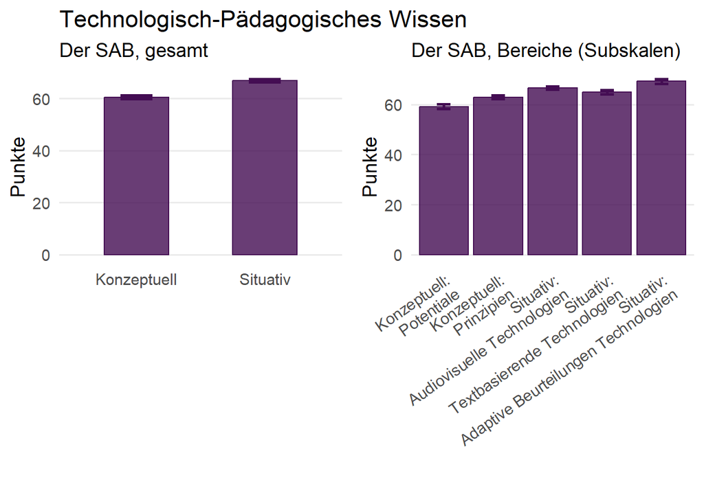

```r
rm(nrw_p)
nrw_p <- nrw |>
  dplyr::select(kohorte, gruppe,
                tpkpot_score,
                tpksup_score,
                tpksit_score_av,
                tpksit_score_tb,
                tpksit_score_aa) |>
  dplyr::filter(kohorte %in% c("4") & gruppe %in% c("sab")) |>
  pivot_longer(3:7, names_to = "variables", values_to = "values")

p2 <- ggplot(nrw_p, aes(x=factor(variables,
                                 levels = c("tpkpot_score",
                                            "tpksup_score",
                                            "tpksit_score_av",
                                            "tpksit_score_tb",
                                            "tpksit_score_aa")),
                        y = values, fill = kohorte, color = kohorte)) +
  stat_summary(geom = "bar", alpha = .8,
               position = position_dodge2(width = 1, preserve = "single")) +
  stat_summary(linewidth = 1, geom = "errorbar",
               width = .25, position = position_dodge(width = .9)) +
  scale_fill_manual(values = c(#"#fce725",
                               #"#37b877",
                               #"#34608d",
                               "#440d53")) +
  scale_color_manual(values = c(#"#fce725",
                               #"#37b877",
                               #"#34608d",
                               "#440d53")) +
  scale_x_discrete(labels = c("Konzeptuell:\nPotentiale",
                              "Konzeptuell:\nPrinzipien",
                              "Situativ:\nAudiovisuelle Technologien",
                              "Situativ:\nTextbasierende Technologien",
                              "Situativ:\nAdaptive Beurteilungen Technologien")) +
  xlab("") +
  ylab("Punkte") +
  labs(title = "Technologisch-Pädagogisches Wissen",
       subtitle = "Der SAB, Bereiche (Subskalen)",
       caption = "",
       fill = "Kohorte",
       color = "Kohorte") +
  theme_minimal(base_size = 14) +
  theme(axis.text.x = element_text(angle = 35, vjust = 1, hjust=1),
        panel.grid.major.x = element_blank(),
        panel.grid.minor.y = element_blank())

ggarrange(p1, p2 + labs(title = ""),
          ncol = 2,
          align = "hv",
          common.legend = T,
          legend = "none")
```

**LAA vs. SAB: TPK konzeptuell**  
*t-Test*

```r
t.test(tpkcon_score ~ gruppe,
       data = nrw |> dplyr::filter(kohorte %in% c("4") &
                                   gruppe %in% c("laa", "sab")))
```

```
    Welch Two Sample t-test

data:  tpkcon_score by gruppe
t = 2.0843, df = 308.01, p-value = 0.03795
alternative hypothesis: true difference in means between group laa and group sab is not equal to 0
95 percent confidence interval:
 0.09399273 3.26569525
sample estimates:
mean in group laa mean in group sab
         62.21109          60.53125
```

*Cohen’s d*

```r
cohens_d <- psych::cohen.d(tpkcon_score ~ gruppe,
                           data = nrw |> dplyr::filter(kohorte %in% c("4") &
                                                       gruppe %in% c("laa", "sab")))
cohens_d$cohen.d
```

```
                  lower     effect       upper
tpkcon_score -0.3358165 -0.1771312 -0.01834337
```

*Overlap*  
in Prozent

```r
2 * pnorm(-abs(cohens_d$cohen.d[1, "effect"]) / 2) * 100
```

```
[1] 92.94271
```

**LAA vs. SAB: TPK situativ**  
*t-Test*

```r
t.test(tpksit_score ~ gruppe,
       data = nrw |> dplyr::filter(kohorte %in% c("4") &
                                   gruppe %in% c("laa", "sab")))
```

```
    Welch Two Sample t-test

data:  tpksit_score by gruppe
t = 2.2369, df = 314.16, p-value = 0.02599
alternative hypothesis: true difference in means between group laa and group sab is not equal to 0
95 percent confidence interval:
 0.1790069 2.7937396
sample estimates:
mean in group laa mean in group sab
         68.33012          66.84375
```

*Cohen’s d*

```r
cohens_d <- psych::cohen.d(tpksit_score ~ gruppe,
                           data = nrw |> dplyr::filter(kohorte %in% c("4") &
                                                       gruppe %in% c("laa", "sab")))
cohens_d$cohen.d
```

```
                  lower    effect       upper
tpksit_score -0.3461913 -0.187482 -0.02866222
```

*Overlap*  
in Prozent

```r
2 * pnorm(-abs(cohens_d$cohen.d[1, "effect"]) / 2) * 100
```

```
[1] 92.53149
```

### 3.3.2 Überzeugungen über das Lernen

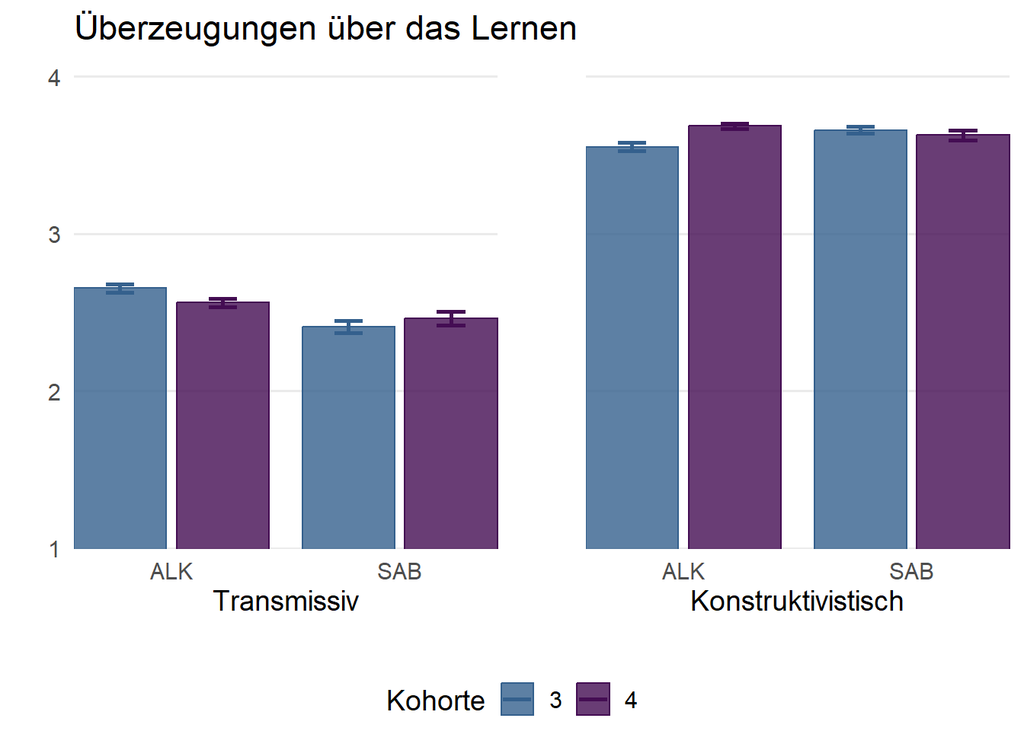

```r
rm(nrw_p)
nrw_p <- nrw |>
  dplyr::filter(kohorte %in% c("3", "4")) |>
  dplyr::filter(gruppe %in% c("alk", "sab"))

p1 <- ggplot(nrw_p, aes(x = gruppe,
                        y = uebr,
                        fill = kohorte,
                        color = kohorte)) +
  stat_summary(geom = "bar", alpha = .8,
               position = position_dodge2(width = 1)) +
  stat_summary(linewidth = 1, geom = "errorbar",
               width = .25, position = position_dodge(width = .9)) +
  scale_fill_manual(values = c(#"#fce725",
                                #"#37b877",
                                "#34608d",
                                "#440d53")) +
  scale_color_manual(values = c(#"#fce725",
                                #"#37b877",
                                "#34608d",
                                "#440d53")) +
  scale_x_discrete(labels = c("ALK",
                              "SAB")) +
  coord_cartesian(ylim = c(1,4.1),
                  expand = F) +
  xlab("Transmissiv") +
  ylab("") +
  labs(title = "Überzeugungen über das Lernen",
       caption = "",
       fill = "Kohorte",
       color = "Kohorte") +
  theme_minimal(base_size = 14) +
  theme(#axis.text.x = element_text(angle = 35, vjust = 1, hjust=1),
        panel.grid.major.x = element_blank(),
        panel.grid.minor.y = element_blank(),
        plot.subtitle=element_text(face="italic"))

p2 <- ggplot(nrw_p, aes(x = gruppe,
                        y = uebk,
                        fill = kohorte,
                        color = kohorte)) +
  stat_summary(geom = "bar", alpha = .8,
               position = position_dodge2(width = 1)) +
  stat_summary(linewidth = 1, geom = "errorbar",
               width = .25, position = position_dodge(width = .9)) +
  scale_fill_manual(values = c(#"#fce725",
                                #"#37b877",
                                "#34608d",
                                "#440d53")) +
  scale_color_manual(values = c(#"#fce725",
                                #"#37b877",
                                "#34608d",
                                "#440d53")) +
  scale_x_discrete(labels = c("ALK",
                              "SAB")) +
  coord_cartesian(ylim = c(1,4.1),
                  expand = F) +
  xlab("Konstruktivistisch") +
  ylab("") +
  labs(title = "Überzeugungen über das Lernen",
       caption = "",
       fill = "Kohorte",
       color = "Kohorte") +
  theme_minimal(base_size = 14) +
  theme(#axis.text.x = element_text(angle = 35, vjust = 1, hjust=1),
        panel.grid.major.x = element_blank(),
        panel.grid.minor.y = element_blank(),
        plot.subtitle=element_text(face="italic"))



ggarrange(p1,
          p2 +
            labs(title = "") +
            theme(axis.text.y = element_blank()),
          ncol = 2,
          align = "hv",
          common.legend = T,
          legend = "bottom")
```

**Überzeugungen über das Lernen: Transmissiv**  
*t-Test*  
ALK: K3 vs. K4

```r
t.test(uebr ~ kohorte,
       data = nrw |> dplyr::filter(kohorte %in% c("3", "4") &
                                   gruppe %in% c("alk")))
```

```
    Welch Two Sample t-test

data:  uebr by kohorte
t = 2.4631, df = 654.8, p-value = 0.01403
alternative hypothesis: true difference in means between group 3 and group 4 is not equal to 0
95 percent confidence interval:
 0.01835849 0.16268635
sample estimates:
mean in group 3 mean in group 4
       2.653172        2.562650
```

*Cohen’s d*

```r
cohens_d <- psych::cohen.d(uebr ~ kohorte,
                           data = nrw |> dplyr::filter(kohorte %in% c("3", "4") &
                                                       gruppe %in% c("alk")))
cohens_d$cohen.d
```

```
         lower     effect       upper
uebr -0.344465 -0.1916584 -0.03870836
```

*Overlap*  
in Prozent

```r
2 * pnorm(-abs(cohens_d$cohen.d[1, "effect"]) / 2) * 100
```

```
[1] 92.36562
```

**Überzeugungen über das Lernen: Transmissiv**  
*t-Test*  
SAB: K3 vs. K4

```r
t.test(uebr ~ kohorte,
       data = nrw |> dplyr::filter(kohorte %in% c("3", "4") &
                                   gruppe %in% c("sab")))
```

```
    Welch Two Sample t-test

data:  uebr by kohorte
t = -0.87523, df = 271.92, p-value = 0.3822
alternative hypothesis: true difference in means between group 3 and group 4 is not equal to 0
95 percent confidence interval:
 -0.16642358  0.06398938
sample estimates:
mean in group 3 mean in group 4
       2.410006        2.461224
```

*Cohen’s d*

```r
cohens_d <- psych::cohen.d(uebr ~ kohorte,
                           data = nrw |> dplyr::filter(kohorte %in% c("3", "4") &
                                                       gruppe %in% c("sab")))
cohens_d$cohen.d
```

```
          lower    effect     upper
uebr -0.1269875 0.1028402 0.3324946
```

*Overlap*  
in Prozent

```r
2 * pnorm(-abs(cohens_d$cohen.d[1, "effect"]) / 2) * 100
```

```
[1] 95.89908
```

**Überzeugungen über das Lernen: Konstruktivistisch**  
*t-Test*  
ALK: K3 vs. K4

```r
t.test(uebk ~ kohorte,
       data = nrw |> dplyr::filter(kohorte %in% c("3", "4") &
                                   gruppe %in% c("alk")))
```

```
    Welch Two Sample t-test

data:  uebk by kohorte
t = -3.9304, df = 587.97, p-value = 9.49e-05
alternative hypothesis: true difference in means between group 3 and group 4 is not equal to 0
95 percent confidence interval:
 -0.19685515 -0.06567109
sample estimates:
mean in group 3 mean in group 4
       3.553567        3.684830
```

*Cohen’s d*

```r
cohens_d <- psych::cohen.d(uebk ~ kohorte,
                           data = nrw |> dplyr::filter(kohorte %in% c("3", "4") &
                                                       gruppe %in% c("alk")))
cohens_d$cohen.d
```

```
         lower    effect     upper
uebk 0.1441773 0.2976593 0.4509186
```

*Overlap*  
in Prozent

```r
2 * pnorm(-abs(cohens_d$cohen.d[1, "effect"]) / 2) * 100
```

```
[1] 88.16881
```

**Überzeugungen über das Lernen: Konstruktivistisch**  
*t-Test*  
SAB: K3 vs. K4

```r
t.test(uebk ~ kohorte,
       data = nrw |> dplyr::filter(kohorte %in% c("3", "4") &
                                   gruppe %in% c("sab")))
```

```
    Welch Two Sample t-test

data:  uebk by kohorte
t = 0.85973, df = 236.66, p-value = 0.3908
alternative hypothesis: true difference in means between group 3 and group 4 is not equal to 0
95 percent confidence interval:
 -0.04066574  0.10364149
sample estimates:
mean in group 3 mean in group 4
       3.658609        3.627122
```

*Cohen’s d*

```r
cohens_d <- psych::cohen.d(uebk ~ kohorte,
                           data = nrw |> dplyr::filter(kohorte %in% c("3", "4") &
                                                       gruppe %in% c("sab")))
cohens_d$cohen.d
```

```
          lower     effect     upper
uebk -0.3338957 -0.1042368 0.1255962
```

*Overlap*  
in Prozent

```r
2 * pnorm(-abs(cohens_d$cohen.d[1, "effect"]) / 2) * 100
```

```
[1] 95.84344
```

### 3.3.3 Arbeitsengangement

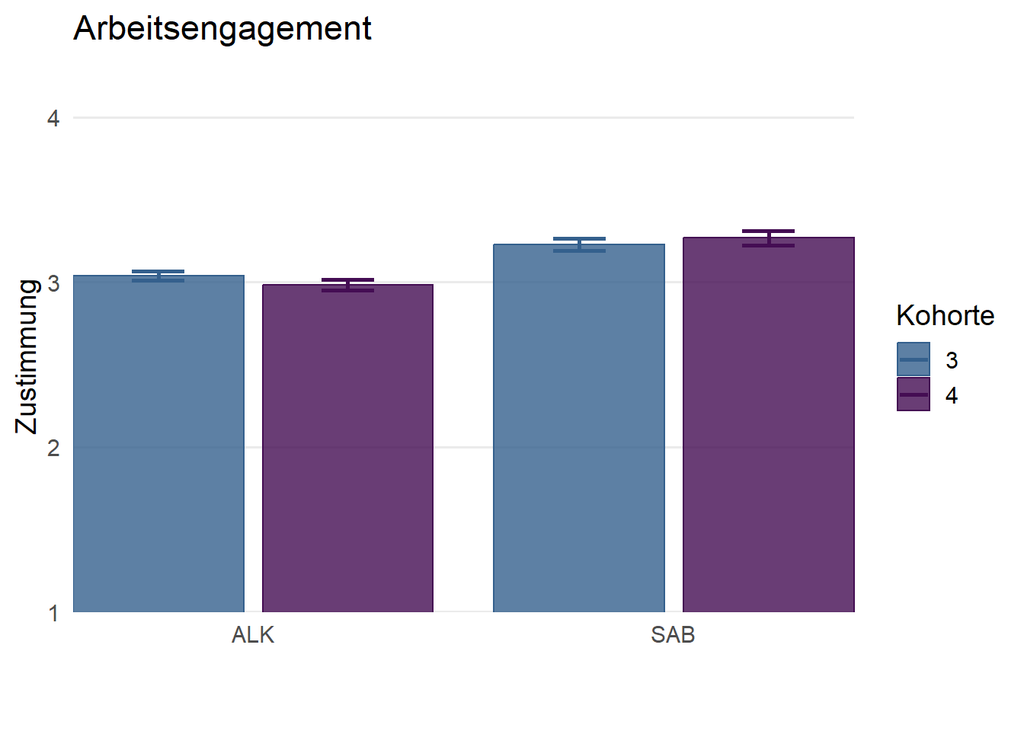

```r
rm(nrw_p)
nrw_p <- nrw |>
  dplyr::filter(kohorte %in% c("3", "4")) |>
  dplyr::filter(gruppe %in% c("alk", "sab"))

p1 <- ggplot(nrw_p, aes(x=gruppe,
                        y = aen,
                        fill = kohorte,
                        color = kohorte)) +
  stat_summary(geom = "bar", alpha = .8,
               position = position_dodge2(width = 1, preserve = "single")) +
  stat_summary(linewidth = 1, geom = "errorbar",
               width = .25, position = position_dodge(width = .9)) +
  scale_fill_manual(values = c(#"#fce725",
                               #"#37b877",
                               "#34608d",
                               "#440d53")) +
  scale_color_manual(values = c(#"#fce725",
                                #"#37b877",
                                "#34608d",
                                "#440d53")) +
  scale_x_discrete(labels = c("ALK",
                              "SAB")) +
  coord_cartesian(ylim = c(1,4.1),
                  expand = F) +
  xlab("") +
  ylab("Zustimmung") +
  labs(title = "Arbeitsengagement",
       subtitle = "",
       caption = "",
       fill = "Kohorte",
       color = "Kohorte") +
  theme_minimal(base_size = 14) +
  theme(panel.grid.major.x = element_blank(),
        panel.grid.minor.y = element_blank())

p1
```

**Arbeitsengangement**  
*t-Test*  
ALK: K3 vs. K4

```r
t.test(aen ~ kohorte,
       data = nrw |> dplyr::filter(kohorte %in% c("3", "4") &
                                     gruppe %in% c("alk")))
```

```
    Welch Two Sample t-test

data:  aen by kohorte
t = 1.2807, df = 597.3, p-value = 0.2008
alternative hypothesis: true difference in means between group 3 and group 4 is not equal to 0
95 percent confidence interval:
 -0.03038271  0.14429076
sample estimates:
mean in group 3 mean in group 4
       3.039274        2.982320
```

*Cohen’s d*

```r
cohens_d <- psych::cohen.d(aen ~ kohorte,
       data = nrw |> dplyr::filter(kohorte %in% c("3", "4") &
                                     gruppe %in% c("alk")))
cohens_d$cohen.d
```

```
         lower     effect     upper
aen -0.2620457 -0.1037649 0.0546007
```

*Overlap*  
in Prozent

```r
2 * pnorm(-abs(cohens_d$cohen.d[1, "effect"]) / 2) * 100
```

```
[1] 95.86223
```

**Arbeitsengangement**  
*t-Test*  
SAB: K3 vs. K4

```r
t.test(aen ~ kohorte,
       data = nrw |> dplyr::filter(kohorte %in% c("3", "4") &
                                     gruppe %in% c("sab")))
```

```
    Welch Two Sample t-test

data:  aen by kohorte
t = -0.7063, df = 268.11, p-value = 0.4806
alternative hypothesis: true difference in means between group 3 and group 4 is not equal to 0
95 percent confidence interval:
 -0.15538280  0.07333393
sample estimates:
mean in group 3 mean in group 4
       3.228321        3.269345
```

*Cohen’s d*

```r
cohens_d <- psych::cohen.d(aen ~ kohorte,
       data = nrw |> dplyr::filter(kohorte %in% c("3", "4") &
                                     gruppe %in% c("sab")))
cohens_d$cohen.d
```

```
         lower     effect     upper
aen -0.1480166 0.08333297 0.3145412
```

*Overlap*  
in Prozent

```r
2 * pnorm(-abs(cohens_d$cohen.d[1, "effect"]) / 2) * 100
```

```
[1] 96.67646
```

**Arbeitsengangement**  
*t-Test*  
K3: SAB vs. ALK

```r
t.test(aen ~ gruppe,
       data = nrw |> dplyr::filter(kohorte %in% c("3") &
                                     gruppe %in% c("sab", "alk")))
```

```
    Welch Two Sample t-test

data:  aen by gruppe
t = -3.9419, df = 360.04, p-value = 9.715e-05
alternative hypothesis: true difference in means between group alk and group sab is not equal to 0
95 percent confidence interval:
 -0.2833606 -0.0947325
sample estimates:
mean in group alk mean in group sab
         3.039274          3.228321
```

*Cohen’s d*

```r
cohens_d <- psych::cohen.d(aen ~ gruppe,
       data = nrw |> dplyr::filter(kohorte %in% c("3") &
                                     gruppe %in% c("sab", "alk")))
cohens_d$cohen.d
```

```
        lower   effect     upper
aen 0.1840251 0.372178 0.5599499
```

*Overlap*  
in Prozent

```r
2 * pnorm(-abs(cohens_d$cohen.d[1, "effect"]) / 2) * 100
```

```
[1] 85.2375
```

**Arbeitsengangement**  
*t-Test*  
K4: SAB vs. ALK

```r
t.test(aen ~ gruppe,
       data = nrw |> dplyr::filter(kohorte %in% c("4") &
                                     gruppe %in% c("sab", "alk")))
```

```
    Welch Two Sample t-test

data:  aen by gruppe
t = -5.1961, df = 271.39, p-value = 4.004e-07
alternative hypothesis: true difference in means between group alk and group sab is not equal to 0
95 percent confidence interval:
 -0.3957755 -0.1782745
sample estimates:
mean in group alk mean in group sab
         2.982320          3.269345
```

*Cohen’s d*

```r
cohens_d <- psych::cohen.d(aen ~ gruppe,
       data = nrw |> dplyr::filter(kohorte %in% c("4") &
                                     gruppe %in% c("sab", "alk")))
cohens_d$cohen.d
```

```
        lower    effect     upper
aen 0.3037141 0.5159181 0.7275299
```

*Overlap*  
in Prozent

```r
2 * pnorm(-abs(cohens_d$cohen.d[1, "effect"]) / 2) * 100
```

```
[1] 79.64385
```

### 3.3.4 Seminargestaltung

- **Wahrgenommene Integration von Theorie und Praxis im Studienseminar**
- **Externale Kontrollüberzeugungen als SAB**

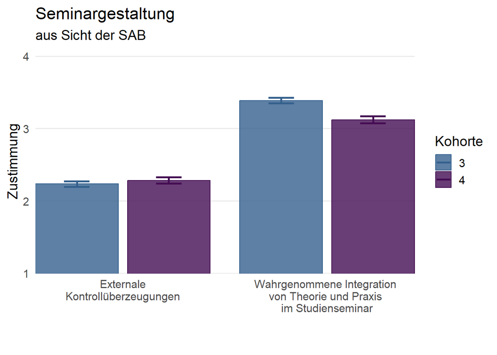

```r
rm(nrw_p)
nrw_p <- nrw |>
  dplyr::filter(kohorte %in% c("3", "4")) |>
  dplyr::filter(gruppe %in% c("alk", "sab")) |>
  dplyr::select(kohorte, gruppe, EXKO, SETH_FA, SETH_KA, TPZU) |>
  pivot_longer(3:6, names_to = "variables", values_to = "values") |>
  mutate(variables = case_when(
                        variables == "SETH_FA" | variables == "SETH_KA" ~ "TPZU",
                        TRUE ~ variables))

p1 <- ggplot(nrw_p, aes(x = variables,
                        y = values,
                        fill = kohorte,
                        color = kohorte)) +
  stat_summary(geom = "bar", alpha = .8,
               position = position_dodge2(width = 1, preserve = "single")) +
  stat_summary(linewidth = 1, geom = "errorbar",
               width = .25, position = position_dodge(width = .9)) +
  scale_fill_manual(values = c(#"#fce725",
                               #"#37b877",
                               "#34608d",
                               "#440d53")) +
  scale_color_manual(values = c(#"#fce725",
                                #"#37b877",
                                "#34608d",
                                "#440d53")) +
  scale_x_discrete(labels = c("Externale\nKontrollüberzeugungen",
                              "Wahrgenommene Integration \nvon Theorie und Praxis \nim Studienseminar")) +
  coord_cartesian(ylim = c(1,4.1),
                  expand = F) +
  xlab("") +
  ylab("Zustimmung") +
  labs(title = "Seminargestaltung",
       subtitle = "aus Sicht der SAB",
       caption = "",
       fill = "Kohorte",
       color = "Kohorte") +
  theme_minimal(base_size = 14) +
  theme(panel.grid.major.x = element_blank(),
        panel.grid.minor.y = element_blank())

p1
```

**Externale Kontrollüberzeugung**  
*t-Test*  
K3 vs. K4

```r
t.test(EXKO ~ kohorte,
       data = nrw |> dplyr::filter(kohorte %in% c("3", "4") &
                                     gruppe %in% c("sab")))
```

```
    Welch Two Sample t-test

data:  EXKO by kohorte
t = -0.84868, df = 276.9, p-value = 0.3968
alternative hypothesis: true difference in means between group 3 and group 4 is not equal to 0
95 percent confidence interval:
 -0.16451297  0.06539556
sample estimates:
mean in group 3 mean in group 4
       2.233237        2.282796
```

*Cohen’s d*

```r
cohens_d <- psych::cohen.d(EXKO ~ kohorte,
                           data = nrw |> dplyr::filter(kohorte %in% c("3", "4") &
                                                       gruppe %in% c("sab")))
cohens_d$cohen.d
```

```
          lower     effect     upper
EXKO -0.1319608 0.09887768 0.3295511
```

*Overlap*  
in Prozent

```r
2 * pnorm(-abs(cohens_d$cohen.d[1, "effect"]) / 2) * 100
```

```
[1] 96.05696
```

**Wahrgenommene Integration von Theorie und Praxis**  
*t-Test*  
K3 vs. K4

```r
nrw_p <- nrw |>
  dplyr::filter(kohorte %in% c("3", "4")) |>
  dplyr::filter(gruppe %in% c("sab")) |>
  dplyr::select(kohorte, gruppe, SETH_FA, SETH_KA, TPZU) |>
  pivot_longer(3:5, names_to = "variables", values_to = "values") |>
  mutate(variables = case_when(
                        variables == "SETH_FA" | variables == "SETH_KA" ~ "TPZU",
                        TRUE ~ variables))

t.test(values ~ kohorte,
       data = nrw_p |> dplyr::filter(kohorte %in% c("3", "4") &
                                     gruppe %in% c("sab")))
```

```
    Welch Two Sample t-test

data:  values by kohorte
t = 4.2627, df = 263.71, p-value = 2.814e-05
alternative hypothesis: true difference in means between group 3 and group 4 is not equal to 0
95 percent confidence interval:
 0.1432218 0.3891116
sample estimates:
mean in group 3 mean in group 4
       3.387500        3.121333
```

*Cohen’s d*

```r
cohens_d <- psych::cohen.d(values ~ kohorte,
                           data = nrw_p |> dplyr::filter(kohorte %in% c("3", "4") &
                                                         gruppe %in% c("sab")))
cohens_d$cohen.d
```

```
            lower     effect     upper
values -0.7308341 -0.4996011 -0.267567
```

*Overlap*  
in Prozent

```r
2 * pnorm(-abs(cohens_d$cohen.d[1, "effect"]) / 2) * 100
```

```
[1] 80.27416
```

**Innovationsbereitschaft**

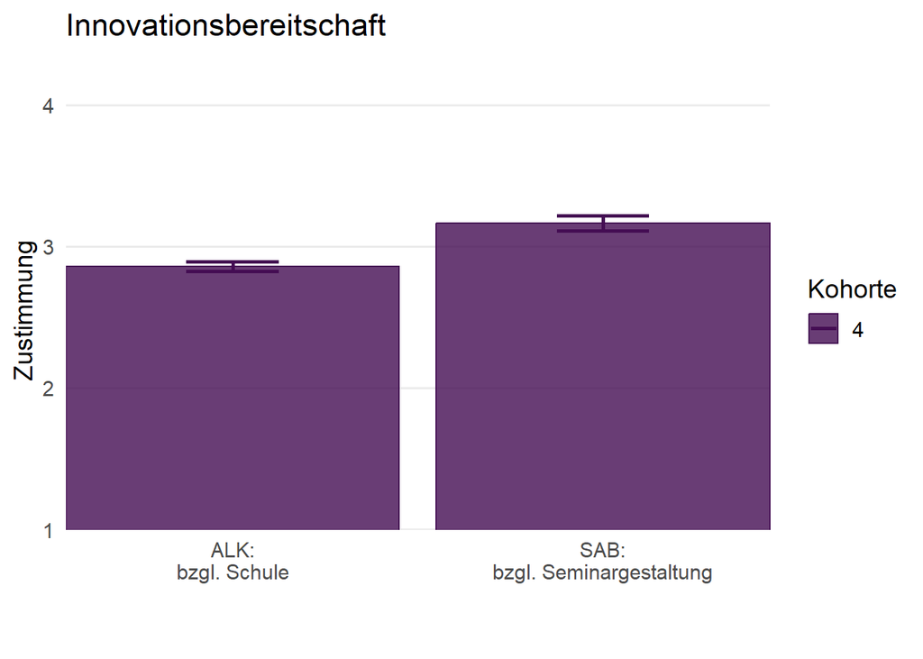

```r
rm(nrw_p)
nrw_p <- nrw |>
  dplyr::filter(kohorte %in% c("3", "4")) |>
  dplyr::filter(gruppe %in% c("alk", "sab"))

p1 <- ggplot(nrw_p, aes(x = gruppe,
                        y = INNO,
                        fill = kohorte,
                        color = kohorte)) +
  stat_summary(geom = "bar", alpha = .8,
               position = position_dodge2(width = 1, preserve = "single")) +
  stat_summary(linewidth = 1, geom = "errorbar",
               width = .25, position = position_dodge(width = .9)) +
  scale_fill_manual(values = c(#"#fce725",
                               #"#37b877",
                               #"#34608d",
                               "#440d53")) +
  scale_color_manual(values = c(#"#fce725",
                                #"#37b877",
                                #"#34608d",
                                "#440d53")) +
  scale_x_discrete(labels = c("ALK:\nbzgl. Schule",
                              "SAB:\nbzgl. Seminargestaltung")) +
  coord_cartesian(ylim = c(1,4.1),
                  expand = F) +
  xlab("") +
  ylab("Zustimmung") +
  labs(title = "Innovationsbereitschaft",
       subtitle = "",
       caption = "",
       fill = "Kohorte",
       color = "Kohorte") +
  theme_minimal(base_size = 14) +
  theme(panel.grid.major.x = element_blank(),
        panel.grid.minor.y = element_blank())

p1
```

**Innovationsbereitschaft**  
*t-Test*  
ALK vs. SAB

```r
t.test(INNO ~ gruppe,
       data = nrw |> dplyr::filter(kohorte %in% c("4") &
                                   gruppe %in% c("alk", "sab")))
```

```
    Welch Two Sample t-test

data:  INNO by gruppe
t = -4.8083, df = 230.16, p-value = 2.751e-06
alternative hypothesis: true difference in means between group alk and group sab is not equal to 0
95 percent confidence interval:
 -0.4320543 -0.1808843
sample estimates:
mean in group alk mean in group sab
         2.860197          3.166667
```

*Cohen’s d*

```r
cohens_d <- psych::cohen.d(INNO ~ gruppe,
                           data = nrw |> dplyr::filter(kohorte %in% c("4") &
                                                       gruppe %in% c("alk", "sab")))
cohens_d$cohen.d
```

```
         lower    effect     upper
INNO 0.2960953 0.5092211 0.7217617
```

*Overlap*  
in Prozent

```r
2 * pnorm(-abs(cohens_d$cohen.d[1, "effect"]) / 2) * 100
```

```
[1] 79.90239
```

### 3.3.5 Wohlbefinden

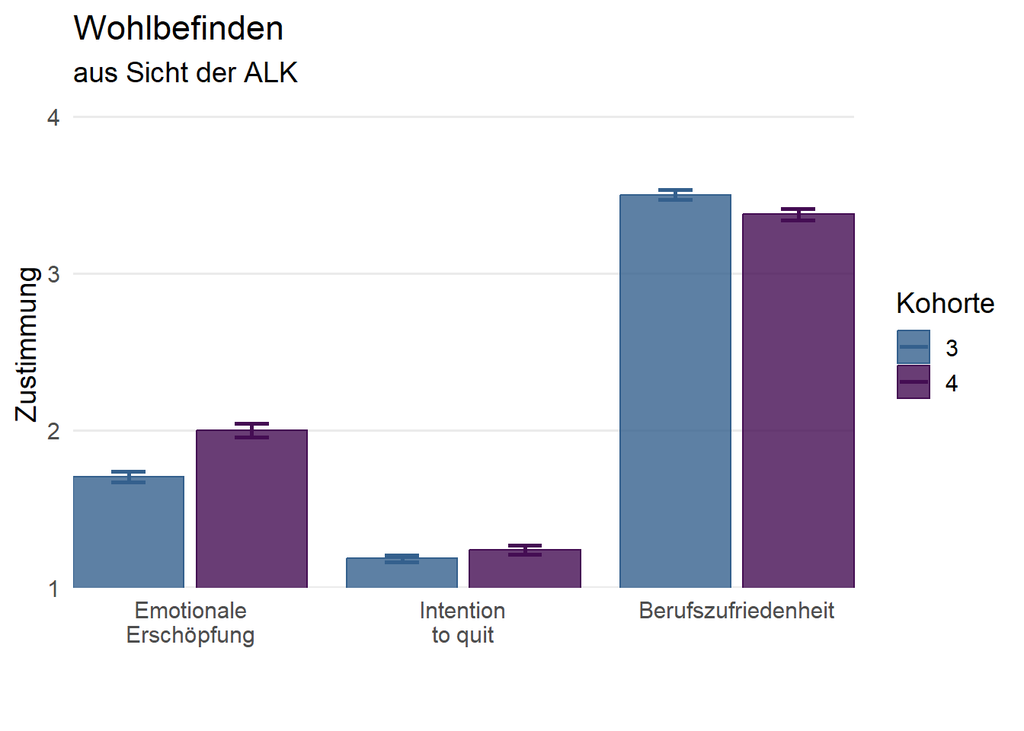

```r
rm(nrw_p)
nrw_p <- nrw |>
  dplyr::filter(kohorte %in% c("3", "4")) |>
  dplyr::filter(gruppe %in% c("alk")) |>
  dplyr::select(kohorte, gruppe, bel, zfr, QUIT) |>
  pivot_longer(3:5, names_to = "variables", values_to = "values")

p1 <- ggplot(nrw_p, aes(x = variables,
                        y = values,
                        fill = kohorte,
                        color = kohorte)) +
  stat_summary(geom = "bar", alpha = .8,
               position = position_dodge2(width = 1, preserve = "single")) +
  stat_summary(linewidth = 1, geom = "errorbar",
               width = .25, position = position_dodge(width = .9)) +
  scale_fill_manual(values = c(#"#fce725",
                               #"#37b877",
                               "#34608d",
                               "#440d53")) +
  scale_color_manual(values = c(#"#fce725",
                                #"#37b877",
                                "#34608d",
                                "#440d53")) +
  scale_x_discrete(labels = c("Emotionale\nErschöpfung",
                              "Intention\nto quit",
                              "Berufszufriedenheit")) +
  coord_cartesian(ylim = c(1,4.1),
                  expand = F) +
  xlab("") +
  ylab("Zustimmung") +
  labs(title = "Wohlbefinden",
       subtitle = "aus Sicht der ALK",
       caption = "",
       fill = "Kohorte",
       color = "Kohorte") +
  theme_minimal(base_size = 14) +
  theme(panel.grid.major.x = element_blank(),
        panel.grid.minor.y = element_blank())

p1
```

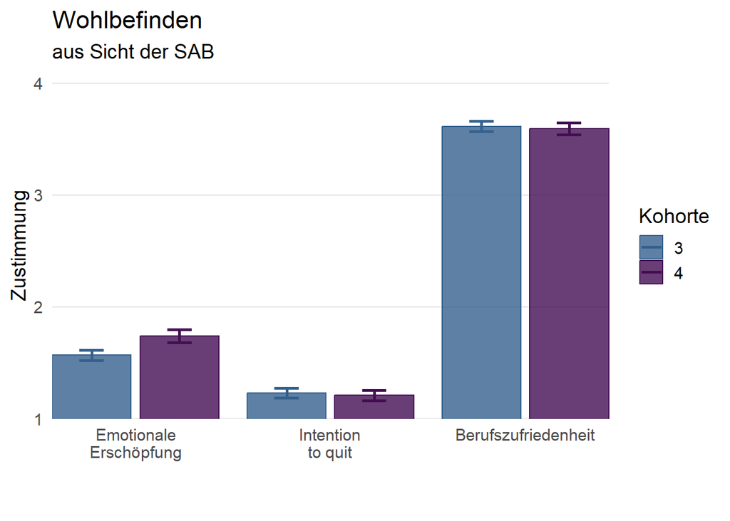

```r
rm(nrw_p)
nrw_p <- nrw |>
  dplyr::filter(kohorte %in% c("3", "4")) |>
  dplyr::filter(gruppe %in% c("sab")) |>
  dplyr::select(kohorte, gruppe, bel, zfr, QUIT) |>
  pivot_longer(3:5, names_to = "variables", values_to = "values")

p1 <- ggplot(nrw_p, aes(x = variables,
                        y = values,
                        fill = kohorte,
                        color = kohorte)) +
  stat_summary(geom = "bar", alpha = .8,
               position = position_dodge2(width = 1, preserve = "single")) +
  stat_summary(linewidth = 1, geom = "errorbar",
               width = .25, position = position_dodge(width = .9)) +
  scale_fill_manual(values = c(#"#fce725",
                               #"#37b877",
                               "#34608d",
                               "#440d53")) +
  scale_color_manual(values = c(#"#fce725",
                                #"#37b877",
                                "#34608d",
                                "#440d53")) +
  scale_x_discrete(labels = c("Emotionale\nErschöpfung",
                              "Intention\nto quit",
                              "Berufszufriedenheit")) +
  coord_cartesian(ylim = c(1,4.1),
                  expand = F) +
  xlab("") +
  ylab("Zustimmung") +
  labs(title = "Wohlbefinden",
       subtitle = "aus Sicht der SAB",
       caption = "",
       fill = "Kohorte",
       color = "Kohorte") +
  theme_minimal(base_size = 14) +
  theme(panel.grid.major.x = element_blank(),
        panel.grid.minor.y = element_blank())

p1
```

### 3.3.6 Partizipation der LAA

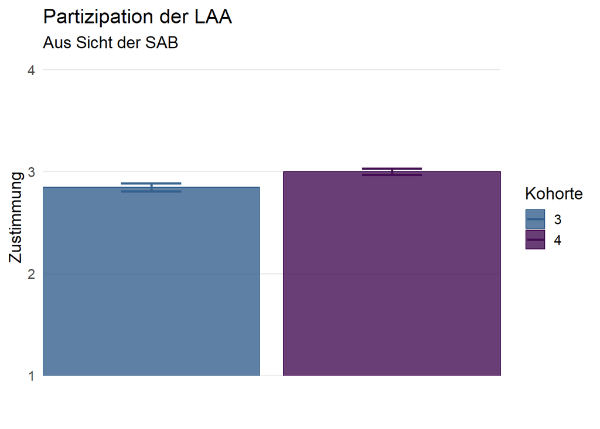

```r
rm(nrw_p)
nrw_p <- nrw |>
  dplyr::filter(kohorte %in% c("3", "4")) |>
  dplyr::filter(gruppe %in% c("sab")) |>
  dplyr::select(kohorte, gruppe, SExMPART, SExFAP, SExKAP) |> # sind jeweils die Skalen, nur von unterschiedlichen Personen beantwortet, deshalb werden alle drei Skalen benötigt
  pivot_longer(3:5, names_to = "variables", values_to = "values")

p1 <- ggplot(nrw_p, aes(x = kohorte,
                        y = values,
                        fill = kohorte,
                        color = kohorte)) +
  stat_summary(geom = "bar", alpha = .8,
               position = position_dodge2(width = 1, preserve = "single")) +
  stat_summary(linewidth = 1, geom = "errorbar",
               width = .25, position = position_dodge(width = .9)) +
  scale_fill_manual(values = c(#"#fce725",
                               #"#37b877",
                               "#34608d",
                               "#440d53")) +
  scale_color_manual(values = c(#"#fce725",
                                #"#37b877",
                                "#34608d",
                                "#440d53")) +
  # scale_x_discrete(labels = c("ALK:\nbzgl. Schule",
  #                             "SAB:\nbzgl. Seminargestaltung")) +
  coord_cartesian(ylim = c(1,4.1),
                  expand = F) +
  xlab("") +
  ylab("Zustimmung") +
  labs(title = "Partizipation der LAA",
       subtitle = "Aus Sicht der SAB",
       caption = "",
       fill = "Kohorte",
       color = "Kohorte") +
  theme_minimal(base_size = 14) +
  theme(panel.grid.major.x = element_blank(),
        panel.grid.minor.y = element_blank(),
        axis.text.x = element_blank())

p1
```

**Partizipation**  
*t-Test*  
K3 vs. K4

```r
t.test(values ~ kohorte,
       data = nrw_p |> dplyr::filter(kohorte %in% c("3", "4") &
                                     gruppe %in% c("sab")))
```

```
    Welch Two Sample t-test

data:  values by kohorte
t = -3.1573, df = 360.46, p-value = 0.001727
alternative hypothesis: true difference in means between group 3 and group 4 is not equal to 0
95 percent confidence interval:
 -0.24983453 -0.05805941
sample estimates:
mean in group 3 mean in group 4
       2.842831        2.996778
```

*Cohen’s d*

```r
cohens_d <- psych::cohen.d(values ~ kohorte,
                           data = nrw_p |> dplyr::filter(kohorte %in% c("3", "4") &
                                                       gruppe %in% c("sab")))
cohens_d$cohen.d
```

```
           lower    effect     upper
values 0.1203726 0.3108098 0.5009015
```

*Overlap*  
in Prozent

```r
2 * pnorm(-abs(cohens_d$cohen.d[1, "effect"]) / 2) * 100
```

```
[1] 87.65021
```

**Korrelation: Partizipation ~~ Konstruktivistische Überz.** K4 SAB

```r
nrw_p <- nrw |>
  dplyr::filter(kohorte %in% c("4")) |>
  dplyr::filter(gruppe %in% c("sab")) |>
  dplyr::mutate(SEx = case_when(
                        !is.na(SExMPART) ~ SExMPART,
                        !is.na(SExFAP) ~ SExFAP,
                        !is.na(SExKAP) ~ SExKAP,
                        TRUE ~ NA))

cor.test(nrw_p$SEx, nrw_p$uebk, use = "pairwise.complete.obs")
```

```
    Pearson's product-moment correlation

data:  nrw_p$SEx and nrw_p$uebk
t = 0.53268, df = 125, p-value = 0.5952
alternative hypothesis: true correlation is not equal to 0
95 percent confidence interval:
 -0.1276827  0.2199813
sample estimates:
       cor
0.04759055
```

### 3.3.7 Lernziele im VD

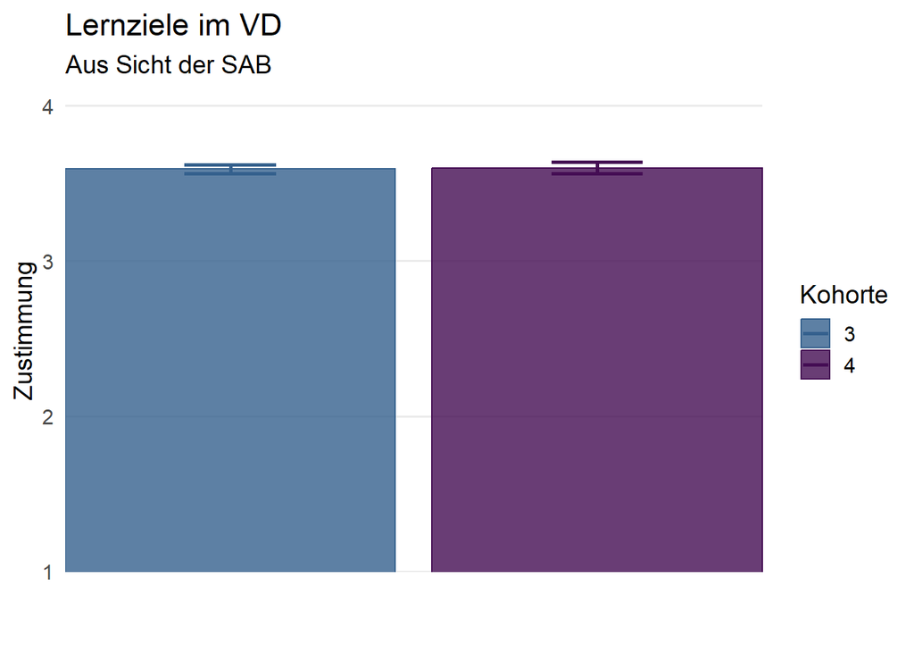

```r
rm(nrw_p)
nrw_p <- nrw |>
  dplyr::filter(kohorte %in% c("3", "4")) |>
  dplyr::filter(gruppe %in% c("sab"))

p1 <- ggplot(nrw_p, aes(x = kohorte,
                        y = LZ,
                        fill = kohorte,
                        color = kohorte)) +
  stat_summary(geom = "bar", alpha = .8,
               position = position_dodge2(width = 1, preserve = "single")) +
  stat_summary(linewidth = 1, geom = "errorbar",
               width = .25, position = position_dodge(width = .9)) +
  scale_fill_manual(values = c(#"#fce725",
                               #"#37b877",
                               "#34608d",
                               "#440d53")) +
  scale_color_manual(values = c(#"#fce725",
                                #"#37b877",
                                "#34608d",
                                "#440d53")) +
  # scale_x_discrete(labels = c("ALK:\nbzgl. Schule",
  #                             "SAB:\nbzgl. Seminargestaltung")) +
  coord_cartesian(ylim = c(1,4.1),
                  expand = F) +
  xlab("") +
  ylab("Zustimmung") +
  labs(title = "Lernziele im VD",
       subtitle = "Aus Sicht der SAB",
       caption = "",
       fill = "Kohorte",
       color = "Kohorte") +
  theme_minimal(base_size = 14) +
  theme(panel.grid.major.x = element_blank(),
        panel.grid.minor.y = element_blank(),
        axis.text.x = element_blank())

p1
```

### 3.3.8 Eignungseinschätzung

#### 3.3.8.1 Item “Sicherheit der Einschätzung”

“Nach dem Vorbereitungsdienst weiß ich genau, ob der/die Lehramtsanwärter_in für den Beruf als Lehrkraft geeignet ist oder nicht.”

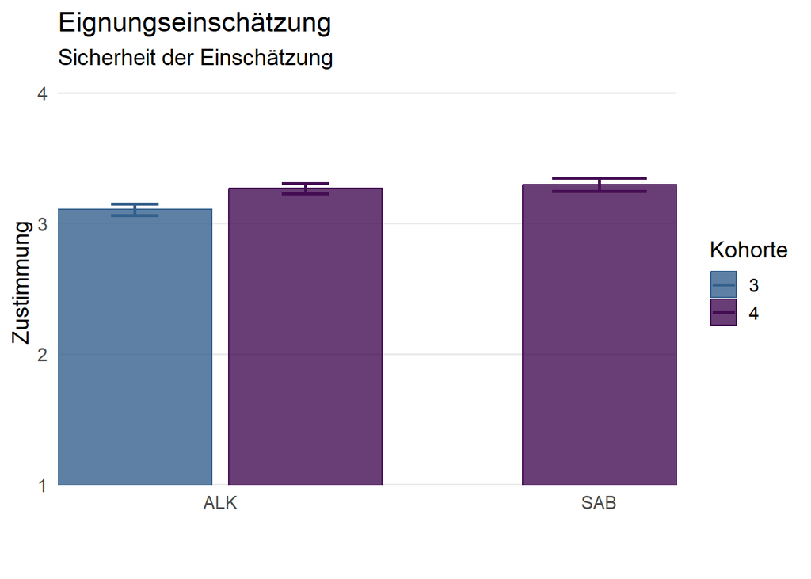

```r
rm(nrw_p)
nrw_p <- nrw |>
  dplyr::filter(kohorte %in% c("3", "4")) |>
  dplyr::filter(gruppe %in% c("alk", "sab"))

p1 <- ggplot(nrw_p, aes(x = gruppe,
                        y = eign_01,
                        fill = kohorte,
                        color = kohorte)) +
  stat_summary(geom = "bar", alpha = .8,
               position = position_dodge2(width = 1, preserve = "single")) +
  stat_summary(linewidth = 1, geom = "errorbar",
               width = .25, position = position_dodge(width = .9)) +
  scale_fill_manual(values = c(#"#fce725",
                               #"#37b877",
                               "#34608d",
                               "#440d53")) +
  scale_color_manual(values = c(#"#fce725",
                                #"#37b877",
                                "#34608d",
                                "#440d53")) +
  scale_x_discrete(labels = c("ALK",
                              "SAB")) +
  coord_cartesian(ylim = c(1,4.1),
                  expand = F) +
  xlab("") +
  ylab("Zustimmung") +
  labs(title = "Eignungseinschätzung",
       subtitle = "Sicherheit der Einschätzung",
       caption = "",
       fill = "Kohorte",
       color = "Kohorte") +
  theme_minimal(base_size = 14) +
  theme(panel.grid.major.x = element_blank(),
        panel.grid.minor.y = element_blank())

p1
```

**Item “Sicherheit der Einschätzung”**  
*t-Test*  
ALK: K3 vs. K4

```r
t.test(eign_01 ~ kohorte,
       data = nrw |> dplyr::filter(kohorte %in% c("3", "4") &
                                   gruppe %in% c("alk")))
```

```
    Welch Two Sample t-test

data:  eign_01 by kohorte
t = -2.704, df = 673.98, p-value = 0.007023
alternative hypothesis: true difference in means between group 3 and group 4 is not equal to 0
95 percent confidence interval:
 -0.28120229 -0.04461557
sample estimates:
mean in group 3 mean in group 4
       3.106322        3.269231
```

*Cohen’s d*

```r
cohens_d <- psych::cohen.d(eign_01 ~ kohorte,
                           data = nrw |> dplyr::filter(kohorte %in% c("3", "4") &
                                                       gruppe %in% c("alk")))
cohens_d$cohen.d
```

```
             lower    effect     upper
eign_01 0.05619741 0.2063504 0.3563535
```

*Overlap*  
in Prozent

```r
2 * pnorm(-abs(cohens_d$cohen.d[1, "effect"]) / 2) * 100
```

```
[1] 91.78239
```

**Item “Sicherheit der Einschätzung”**  
*t-Test*  
ALK vs. SAB

```r
t.test(eign_01 ~ gruppe,
       data = nrw |> dplyr::filter(kohorte %in% c("4") &
                                   gruppe %in% c("alk", "sab")))
```

```
    Welch Two Sample t-test

data:  eign_01 by gruppe
t = -0.43322, df = 292.48, p-value = 0.6652
alternative hypothesis: true difference in means between group alk and group sab is not equal to 0
95 percent confidence interval:
 -0.15323245  0.09794398
sample estimates:
mean in group alk mean in group sab
         3.269231          3.296875
```

*Cohen’s d*

```r
cohens_d <- psych::cohen.d(eign_01 ~ gruppe,
                           data = nrw |> dplyr::filter(kohorte %in% c("4") &
                                                       gruppe %in% c("alk", "sab")))
cohens_d$cohen.d
```

```
             lower     effect     upper
eign_01 -0.1631484 0.04030497 0.2437124
```

*Overlap*  
in Prozent

```r
2 * pnorm(-abs(cohens_d$cohen.d[1, "effect"]) / 2) * 100
```

```
[1] 98.39217
```

#### 3.3.8.2 Anteil

“Wie groß schätzen Sie den Anteil der Lehramtsanwärter_innen, die Sie an Ihrer Schule im Vorbereitungsdienst erleben und **nicht** für den Lehrerberuf geeignet halten?”

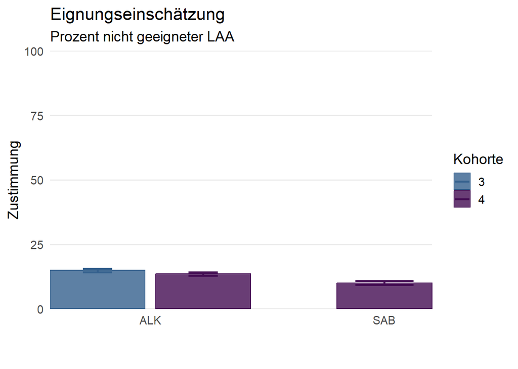

```r
rm(nrw_p)
nrw_p <- nrw |>
  dplyr::filter(kohorte %in% c("3", "4")) |>
  dplyr::filter(gruppe %in% c("alk", "sab"))

p1 <- ggplot(nrw_p, aes(x = gruppe,
                        y = eignp,
                        fill = kohorte,
                        color = kohorte)) +
  stat_summary(geom = "bar", alpha = .8,
               position = position_dodge2(width = 1, preserve = "single")) +
  stat_summary(linewidth = 1, geom = "errorbar",
               width = .25, position = position_dodge(width = .9)) +
  scale_fill_manual(values = c(#"#fce725",
                               #"#37b877",
                               "#34608d",
                               "#440d53")) +
  scale_color_manual(values = c(#"#fce725",
                                #"#37b877",
                                "#34608d",
                                "#440d53")) +
  scale_x_discrete(labels = c("ALK",
                              "SAB")) +
  coord_cartesian(ylim = c(0,100),
                  expand = F) +
  xlab("") +
  ylab("Zustimmung") +
  labs(title = "Eignungseinschätzung",
       subtitle = "Prozent nicht geeigneter LAA",
       caption = "",
       fill = "Kohorte",
       color = "Kohorte") +
  theme_minimal(base_size = 14) +
  theme(panel.grid.major.x = element_blank(),
        panel.grid.minor.y = element_blank())

p1
```

**Anteil**  
*t-Test*  
ALK: K3 vs. K4

```r
t.test(eignp ~ kohorte,
       data = nrw |> dplyr::filter(kohorte %in% c("3", "4") &
                                   gruppe %in% c("alk")))
```

```
    Welch Two Sample t-test

data:  eignp by kohorte
t = 1.3766, df = 662.89, p-value = 0.1691
alternative hypothesis: true difference in means between group 3 and group 4 is not equal to 0
95 percent confidence interval:
 -0.5775407  3.2864547
sample estimates:
mean in group 3 mean in group 4
       14.88676        13.53231
```

*Cohen’s d*

```r
cohens_d <- psych::cohen.d(eignp ~ kohorte,
                           data = nrw |> dplyr::filter(kohorte %in% c("3", "4") &
                                                       gruppe %in% c("alk")))
cohens_d$cohen.d
```

```
           lower     effect      upper
eignp -0.2589871 -0.1068731 0.04532433
```

*Overlap*  
in Prozent

```r
2 * pnorm(-abs(cohens_d$cohen.d[1, "effect"]) / 2) * 100
```

```
[1] 95.73841
```

```r
t.test(eignp ~ gruppe,
       data = nrw |> dplyr::filter(kohorte %in% c("4") &
                                   gruppe %in% c("alk", "sab")))
```

```
    Welch Two Sample t-test

data:  eignp by gruppe
t = 3.3335, df = 291.59, p-value = 0.0009683
alternative hypothesis: true difference in means between group alk and group sab is not equal to 0
95 percent confidence interval:
 1.432302 5.561517
sample estimates:
mean in group alk mean in group sab
         13.53231          10.03540
```

*Cohen’s d*

```r
cohens_d <- psych::cohen.d(eignp ~ gruppe,
                           data = nrw |> dplyr::filter(kohorte %in% c("4") &
                                                       gruppe %in% c("alk", "sab")))
cohens_d$cohen.d
```

```
           lower     effect       upper
eignp -0.5178121 -0.3029949 -0.08783633
```

*Overlap*  
in Prozent

```r
2 * pnorm(-abs(cohens_d$cohen.d[1, "effect"]) / 2) * 100
```

```
[1] 87.95833
```

### 3.3.9 Zusammenarbeit

Kooperation zwischen ZfsL und Ausbildungsschule

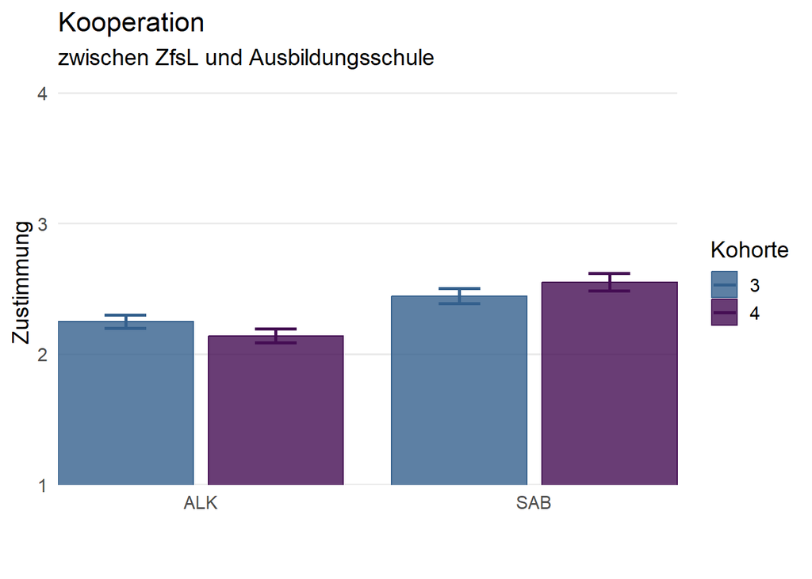

```r
rm(nrw_p)
nrw_p <- nrw |>
  dplyr::filter(kohorte %in% c("3", "4")) |>
  dplyr::filter(gruppe %in% c("alk", "sab"))

p1 <- ggplot(nrw_p, aes(x = gruppe,
                        y = KOZA,
                        fill = kohorte,
                        color = kohorte)) +
  stat_summary(geom = "bar", alpha = .8,
               position = position_dodge2(width = 1, preserve = "single")) +
  stat_summary(linewidth = 1, geom = "errorbar",
               width = .25, position = position_dodge(width = .9)) +
  scale_fill_manual(values = c(#"#fce725",
                               #"#37b877",
                               "#34608d",
                               "#440d53")) +
  scale_color_manual(values = c(#"#fce725",
                                #"#37b877",
                                "#34608d",
                                "#440d53")) +
  scale_x_discrete(labels = c("ALK",
                              "SAB")) +
  coord_cartesian(ylim = c(1,4.1),
                  expand = F) +
  xlab("") +
  ylab("Zustimmung") +
  labs(title = "Kooperation",
       subtitle = "zwischen ZfsL und Ausbildungsschule",
       caption = "",
       fill = "Kohorte",
       color = "Kohorte") +
  theme_minimal(base_size = 14) +
  theme(panel.grid.major.x = element_blank(),
        panel.grid.minor.y = element_blank())

p1
```

**Kooperation**  
*t-Test*  
ALK: K3 vs. K4

```r
t.test(KOZA ~ kohorte,
       data = nrw |> dplyr::filter(kohorte %in% c("3", "4") &
                                   gruppe %in% c("alk")))
```

```
    Welch Two Sample t-test

data:  KOZA by kohorte
t = 1.4947, df = 618.71, p-value = 0.1355
alternative hypothesis: true difference in means between group 3 and group 4 is not equal to 0
95 percent confidence interval:
 -0.03497666  0.25785977
sample estimates:
mean in group 3 mean in group 4
       2.250514        2.139073
```

*Cohen’s d*

```r
cohens_d <- psych::cohen.d(KOZA ~ kohorte,
                           data = nrw |> dplyr::filter(kohorte %in% c("3", "4") &
                                                       gruppe %in% c("alk")))
cohens_d$cohen.d
```

```
          lower     effect      upper
KOZA -0.2766994 -0.1198378 0.03711968
```

*Overlap*  
in Prozent

```r
2 * pnorm(-abs(cohens_d$cohen.d[1, "effect"]) / 2) * 100
```

```
[1] 95.22202
```

**Kooperation**  
*t-Test*  
SAB: K3 vs. K4

```r
t.test(KOZA ~ kohorte,
       data = nrw |> dplyr::filter(kohorte %in% c("3", "4") &
                                   gruppe %in% c("sab")))
```

```
    Welch Two Sample t-test

data:  KOZA by kohorte
t = -1.2224, df = 262.91, p-value = 0.2227
alternative hypothesis: true difference in means between group 3 and group 4 is not equal to 0
95 percent confidence interval:
 -0.27701133  0.06480732
sample estimates:
mean in group 3 mean in group 4
       2.444444        2.550546
```

*Cohen’s d*

```r
cohens_d <- psych::cohen.d(KOZA ~ kohorte,
                           data = nrw |> dplyr::filter(kohorte %in% c("3", "4") &
                                                       gruppe %in% c("sab")))
cohens_d$cohen.d
```

```
           lower    effect     upper
KOZA -0.08767246 0.1450263 0.3774749
```

*Overlap*  
in Prozent

```r
2 * pnorm(-abs(cohens_d$cohen.d[1, "effect"]) / 2) * 100
```

```
[1] 94.21935
```

```r
t.test(KOZA ~ gruppe,
       data = nrw |> dplyr::filter(kohorte %in% c("4") &
                                   gruppe %in% c("alk", "sab")))
```

```
    Welch Two Sample t-test

data:  KOZA by gruppe
t = -4.821, df = 287.15, p-value = 2.319e-06
alternative hypothesis: true difference in means between group alk and group sab is not equal to 0
95 percent confidence interval:
 -0.5794654 -0.2434818
sample estimates:
mean in group alk mean in group sab
         2.139073          2.550546
```

*Cohen’s d*

```r
cohens_d <- psych::cohen.d(KOZA ~ gruppe,
                           data = nrw |> dplyr::filter(kohorte %in% c("4") &
                                                       gruppe %in% c("alk", "sab")))
cohens_d$cohen.d
```

```
         lower    effect     upper
KOZA 0.2526624 0.4655195 0.6778365
```

*Overlap*  
in Prozent

```r
2 * pnorm(-abs(cohens_d$cohen.d[1, "effect"]) / 2) * 100
```

```
[1] 81.5948
```

**Kooperation**  
*t-Test*  
K4: ALK vs. SAB

```r
t.test(KOZA ~ gruppe,
                           data = nrw |> dplyr::filter(kohorte %in% c("4") &
                                                       gruppe %in% c("alk", "sab")))
```

```
    Welch Two Sample t-test

data:  KOZA by gruppe
t = -4.821, df = 287.15, p-value = 2.319e-06
alternative hypothesis: true difference in means between group alk and group sab is not equal to 0
95 percent confidence interval:
 -0.5794654 -0.2434818
sample estimates:
mean in group alk mean in group sab
         2.139073          2.550546
```

*Cohen’s d*

```r
cohens_d <- psych::cohen.d(KOZA ~ gruppe,
                           data = nrw |> dplyr::filter(kohorte %in% c("4") &
                                                       gruppe %in% c("alk", "sab")))
cohens_d$cohen.d
```

```
         lower    effect     upper
KOZA 0.2526624 0.4655195 0.6778365
```

*Overlap*  
in Prozent

```r
2 * pnorm(-abs(cohens_d$cohen.d[1, "effect"]) / 2) * 100
```

```
[1] 81.5948
```

### 3.3.10 Unterstützung durch höhere Ebenen

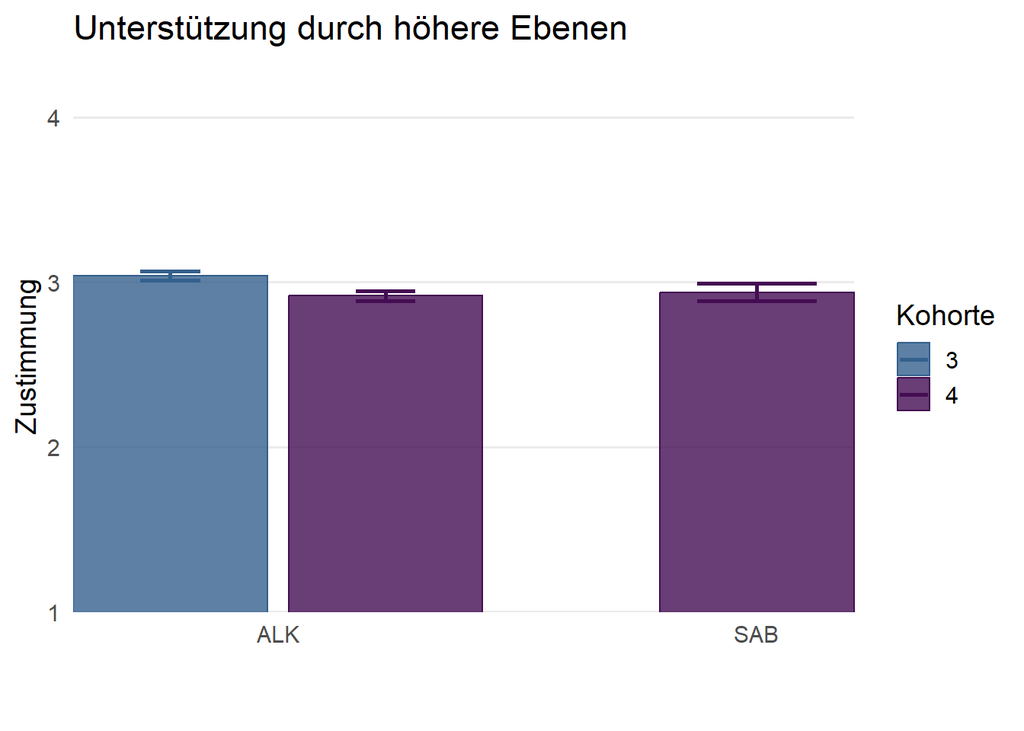

```r
rm(nrw_p)
nrw_p <- nrw |>
  dplyr::filter(kohorte %in% c("3", "4")) |>
  dplyr::filter(gruppe %in% c("alk", "sab"))

p1 <- ggplot(nrw_p, aes(x = gruppe,
                        y = SOZ,
                        fill = kohorte,
                        color = kohorte)) +
  stat_summary(geom = "bar", alpha = .8,
               position = position_dodge2(width = 1, preserve = "single")) +
  stat_summary(linewidth = 1, geom = "errorbar",
               width = .25, position = position_dodge(width = .9)) +
  scale_fill_manual(values = c(#"#fce725",
                               #"#37b877",
                               "#34608d",
                               "#440d53")) +
  scale_color_manual(values = c(#"#fce725",
                                #"#37b877",
                                "#34608d",
                                "#440d53")) +
  scale_x_discrete(labels = c("ALK",
                              "SAB")) +
  coord_cartesian(ylim = c(1,4.1),
                  expand = F) +
  xlab("") +
  ylab("Zustimmung") +
  labs(title = "Unterstützung durch höhere Ebenen",
       subtitle = "",
       caption = "",
       fill = "Kohorte",
       color = "Kohorte") +
  theme_minimal(base_size = 14) +
  theme(panel.grid.major.x = element_blank(),
        panel.grid.minor.y = element_blank())

p1
```

## 3.4 Lerngelegenheiten im Vorbereitungsdienst

### 3.4.1 UB: Sicht der LAA

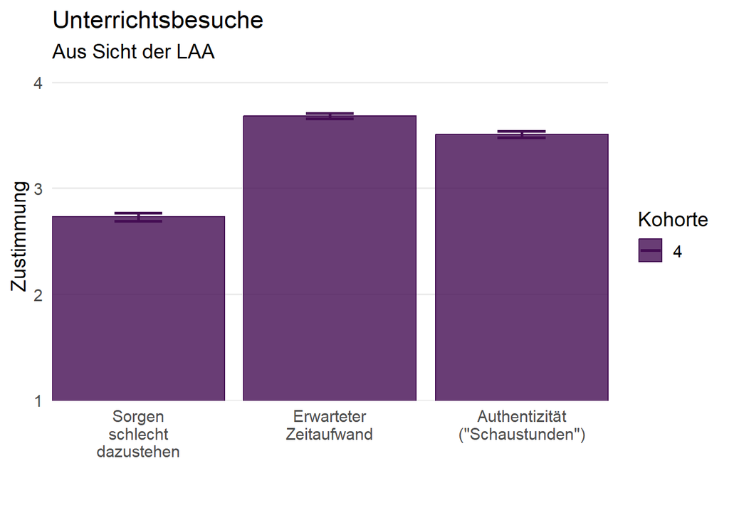

```r
rm(nrw_p)
nrw_p <- nrw |>
  dplyr::filter(kohorte %in% c("4")) |>
  dplyr::filter(gruppe %in% c("laa")) |>
  dplyr::select(kohorte, gruppe, ub_8, ub_3, ub_7) |>
  pivot_longer(3:5, names_to = "variables", values_to = "values")

p1 <- ggplot(nrw_p, aes(x = variables,
                        y = values,
                        fill = kohorte,
                        color = kohorte)) +
  stat_summary(geom = "bar", alpha = .8,
               position = position_dodge2(width = 1, preserve = "single")) +
  stat_summary(linewidth = 1, geom = "errorbar",
               width = .25, position = position_dodge(width = .9)) +
  scale_fill_manual(values = c(#"#fce725",
                               #"#37b877",
                               #"#34608d",
                               "#440d53")) +
  scale_color_manual(values = c(#"#fce725",
                                #"#37b877",
                                #"#34608d",
                                "#440d53")) +
  scale_x_discrete(labels = c("Sorgen\nschlecht\ndazustehen",
                              "Erwarteter\nZeitaufwand",
                              'Authentizität\n("Schaustunden")')) +
  coord_cartesian(ylim = c(1,4.1),
                  expand = F) +
  xlab("") +
  ylab("Zustimmung") +
  labs(title = "Unterrichtsbesuche",
       subtitle = "Aus Sicht der LAA",
       caption = "",
       fill = "Kohorte",
       color = "Kohorte") +
  theme_minimal(base_size = 14) +
  theme(panel.grid.major.x = element_blank(),
        panel.grid.minor.y = element_blank())

p1
```

**Korrelation: Sorgen schlecht dazustehen ~~ Vermeidungszielorientierung**

```r
cor.test(nrw$ub_3, nrw$palvz, use="pairwise.complete.obs")
```

```
    Pearson's product-moment correlation

data:  nrw$ub_3 and nrw$palvz
t = 9.152, df = 627, p-value < 2.2e-16
alternative hypothesis: true correlation is not equal to 0
95 percent confidence interval:
 0.2724181 0.4104446
sample estimates:
      cor
0.3432835
```